# Geography-independent mucosal microbiota alterations in primary sclerosing cholangitis persist after liver transplantation

2. Hypothesis: PSC recurrence is associated with a specific composition of the gut microbiome

# 1 Introduction

## 1.1 About

**rPSC vs non-rPSC vs Healthy analysis on merged data**

- Alpha diversity –> group effect, country effect, interaction effect
- Beta diversity – PERMANOVA, PCA -> group effect, country effect, interaction effect
- DAA ->
  - Group effect – linDA + MaAsLin2 intersection
  - Country effect – taxa with significant interaction effect were excluded based on individual post-hoc analysis. Taxa had to have the same direction in both countries
- ML models, trained and validated using out-of-sample bootstrap (500 resamplings):
- o ENET
- o kNN
- o GBoost
- o RF

Pairwise comparisons:

**rPSC vs non-rPSC** –by this comparison, we will find the effect of recurrence (whether the microbial composition is associated with it)

**non-rPSC vs Healthy** – by this comparison, we will find if the non-rPSC samples are „closer“ to the healthy samples then rPSC samples in terms of the microbial composition. In other words, does non-rPSC samples have „healthy microbiome“?

**rPSC vs Healthy** – by this comparison, we will find how much are the rPSC samples different from healthy samples.

However, the rPSC and non-rPSC samples are not different at all (see results). Therefore, we can do EXCLUSIVE LEFT JOIN of differentially abundant taxa from the analyses (rPSC vs Healthy, non-rPSC vs Healthy)

*Importing libraries and custom functions built for this analysis*

```r
source("custom_functions.R")
```

## 1.2 Data Import

Importing ASV, taxa and metadata tables for both Czech and Norway samples.

**Czech**

```r
path = "../../../../data/analysis_ready_data/ikem/"
asv_tab_ikem <- as.data.frame(fread(file.path(path,"asv_table_ikem.csv"),
                                    check.names = FALSE))
taxa_tab_ikem <- as.data.frame(fread(file.path(path,"taxa_table_ikem.csv"),
                                     check.names = FALSE))
metadata_ikem <- as.data.frame(fread(file.path(path,"metadata_ikem.csv"),
                                     check.names = FALSE))
```

**Norway**

```r
path = "../../../../data/analysis_ready_data/norway/"
asv_tab_norway <- as.data.frame(fread(file.path(path,"asv_table_norway.csv"),
                                    check.names = FALSE))
taxa_tab_norway <- as.data.frame(fread(file.path(path,"taxa_table_norway.csv"),
                                    check.names = FALSE))
metadata_norway <- as.data.frame(fread(file.path(path,"metadata_norway.csv"),
                                    check.names = FALSE))
```

## 1.3 Merging data

Merging two countries to create whole dataset

```r
asv_tab <- merge(asv_tab_ikem,asv_tab_norway,by="SeqID",all=TRUE)
taxa_tab <- merging_taxa_tables(taxa_tab_ikem,taxa_tab_norway)
```

```
Merging at ASV level
```

```
Finding inconsistencies in taxonomy, trying to keep the ones that have better taxonomy assignment
```

Merging two countries based on the different matrices - Ileum, Colon.

**Terminal ileum**

```r
ileum_data <- merging_data(asv_tab_1=asv_tab_ikem,
                           asv_tab_2=asv_tab_norway,
                           taxa_tab_1=taxa_tab_ikem,
                           taxa_tab_2=taxa_tab_norway,
                           metadata_1=metadata_ikem,
                           metadata_2=metadata_norway,
                           segment="TI",Q="Q2")
```

```
Removing 1498 ASV(s)
```

```
Removing 1834 ASV(s)
```

```
Merging at ASV level
```

```
Finding inconsistencies in taxonomy, trying to keep the ones that have better taxonomy assignment
```

```
Removing 641 ASV(s)
```

```r
ileum_asv_tab <- ileum_data[[1]]
ileum_taxa_tab <- ileum_data[[2]]
ileum_metadata <- ileum_data[[3]]
```

**Colon**

```r
colon_data <- merging_data(asv_tab_1=asv_tab_ikem,
                           asv_tab_2=asv_tab_norway,
                           taxa_tab_1=taxa_tab_ikem,
                           taxa_tab_2=taxa_tab_norway,
                           metadata_1=metadata_ikem,
                           metadata_2=metadata_norway,
                           segment="colon",Q="Q2")
```

```
Removing 739 ASV(s)
```

```
Removing 266 ASV(s)
```

```
Merging at ASV level
```

```
Finding inconsistencies in taxonomy, trying to keep the ones that have better taxonomy assignment
```

```
Removing 1096 ASV(s)
```

```r
colon_asv_tab <- colon_data[[1]]
colon_taxa_tab <- colon_data[[2]]
colon_metadata <- colon_data[[3]]
```

# 2 Data Analysis - Terminal ileum

```r
segment="terminal_ileum"
```

## 2.1 Filtering

Rules:

- sequencing depth > 10000
- nearZeroVar() with default settings

**Rarefaction Curve**

```r
path="../../../intermediate_files/rarecurves"
seq_depth_threshold <- 10000
```

```r
ps <- construct_phyloseq(ileum_asv_tab,ileum_taxa_tab,ileum_metadata)
rareres <- get_rarecurve(obj=ps, chunks=500)
save(rareres,file = file.path(path,"rarefaction_ileum.Rdata"))
```

```r
load(file.path(path,"rarefaction_ileum.Rdata"))

prare <- ggrarecurve(obj=rareres,
                      factorNames="Country",
                      indexNames=c("Observe")) +
  theme_bw() +
  theme(axis.text=element_text(size=8), panel.grid=element_blank(),
        strip.background = element_rect(colour=NA,fill="grey"),
        strip.text.x = element_text(face="bold")) +
  geom_vline(xintercept = seq_depth_threshold,
             linetype="dashed",
             color = "red") +
  xlim(0, 20000)
```

```
The color has been set automatically, you can reset it manually by adding scale_color_manual(values=yourcolors)
```

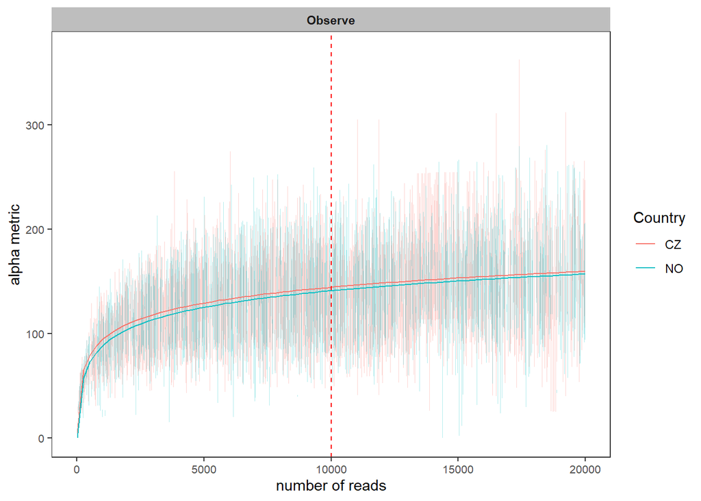

```r
prare
```

**Library size**

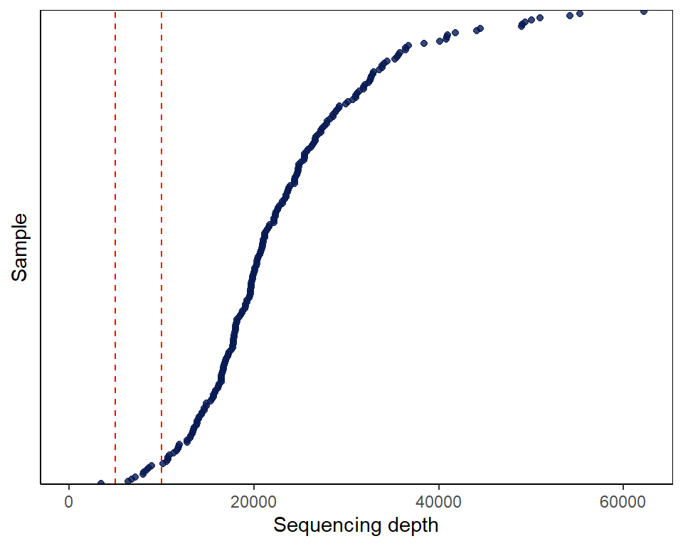

```r
read_counts(ileum_asv_tab, line = c(5000,10000))
```

### 2.1.1 Sequencing depth

```r
data_filt <- seq_depth_filtering(ileum_asv_tab,
                                 ileum_taxa_tab,
                                 ileum_metadata,
                                 seq_depth_threshold = 10000)
```

```
Removing 104 ASV(s)
```

```r
filt_ileum_asv_tab <- data_filt[[1]]; alpha_ileum_asv_tab <- filt_ileum_asv_tab
filt_ileum_taxa_tab <- data_filt[[2]]; alpha_ileum_taxa_tab <- filt_ileum_taxa_tab
filt_ileum_metadata <- data_filt[[3]]; alpha_ileum_metadata <- filt_ileum_metadata

seq_step <- dim(filt_ileum_asv_tab)[1]
```

**Library size**

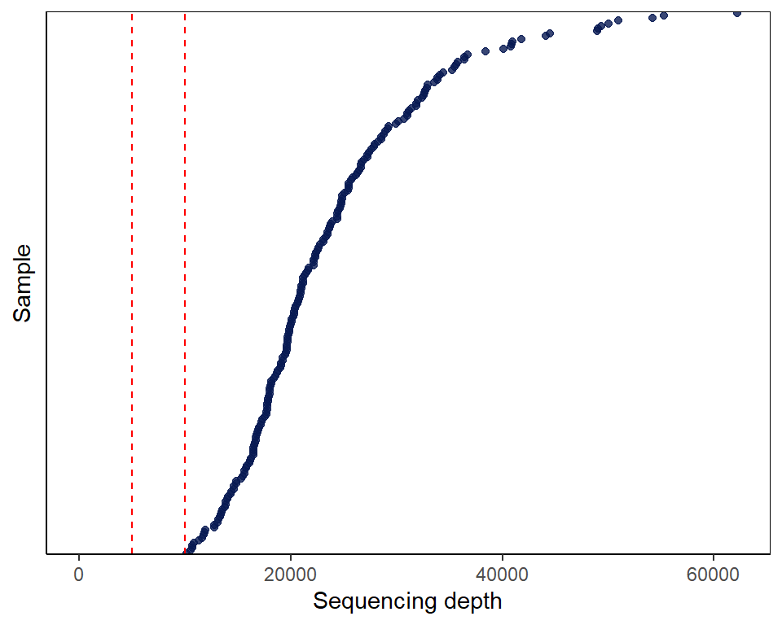

```r
read_counts(filt_ileum_asv_tab,line = c(5000,10000))
```

### 2.1.2 NearZeroVar

```r
data_filt <- nearzerovar_filtering(filt_ileum_asv_tab,
                                   filt_ileum_taxa_tab,
                                   filt_ileum_metadata)

filt_ileum_asv_tab <- data_filt[[1]]
filt_ileum_taxa_tab <- data_filt[[2]]
nearzero_step <- dim(filt_ileum_asv_tab)[1]
```

**Library size**

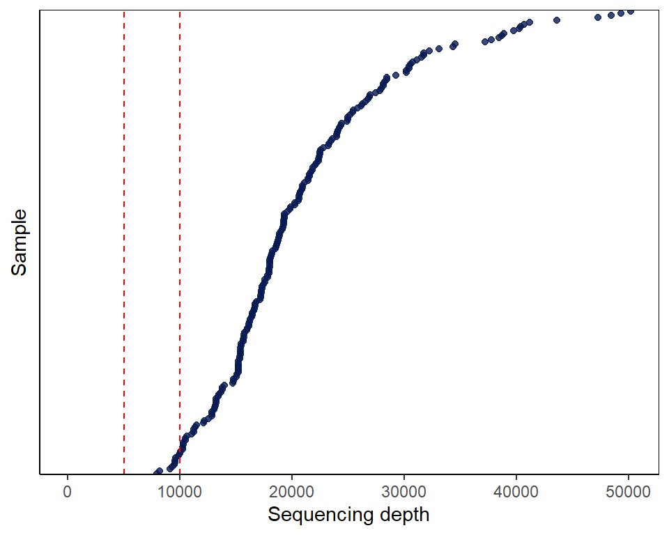

```r
read_counts(filt_ileum_asv_tab,line = c(5000,10000))
```

### 2.1.3 Final Counts

```r
final_counts_filtering(ileum_asv_tab,
                       filt_ileum_asv_tab,
                       filt_ileum_metadata,
                       seq_step, 0, nearzero_step) %>% `colnames<-`("Count")
```

```
                            Count
Raw data: ASVs               4491
Raw data: Samples             220
Sequencing depth filt: ASVs  4387
Prevalence filt: ASVs           0
NearZeroVar filt: ASVs        575
Filt data: ASVs               575
Filt data: Samples            211
Filt data: Patients           211
Filt data: Patients.1           0
Filtered samples                9
Matrices                       TI
healthy                        73
non-rPSC                      105
rPSC                           33
pre_ltx                         0
post_ltx                        0
ETOH                            0
```

## 2.2 Alpha diversity

```r
path = "../../../results/merged_sites/main_analysis/Q2/alpha_diversity"
```

**Calculation**

```r
# Construct MPSE object
alpha_ileum_metadata$Sample <- alpha_ileum_metadata$SampleID
ileum_mpse <- as.MPSE(construct_phyloseq(alpha_ileum_asv_tab,
                                         alpha_ileum_taxa_tab,
                                         alpha_ileum_metadata))

ileum_mpse %<>% mp_rrarefy(raresize = 10000,seed = 123)

# Calculate alpha diversity - rarefied counts
ileum_mpse %<>% mp_cal_alpha(.abundance=RareAbundance, force=TRUE)
```

```r
alpha_div_plots <- list()

# preparing data frame
alpha_data <- data.frame(SampleID=ileum_mpse$Sample.x,
                         Observe=ileum_mpse$Observe,
                         Shannon=ileum_mpse$Shannon,
                         Simpson=ileum_mpse$Simpson,
                         Pielou=ileum_mpse$Pielou,
                         Group=ileum_mpse$Group,
                         Country=ileum_mpse$Country,
                         Patient=ileum_mpse$Patient)

write.csv(alpha_data,file.path(path,paste0("alpha_indices_",segment,".csv")),
          row.names = FALSE)
```

### 2.2.1 Plots

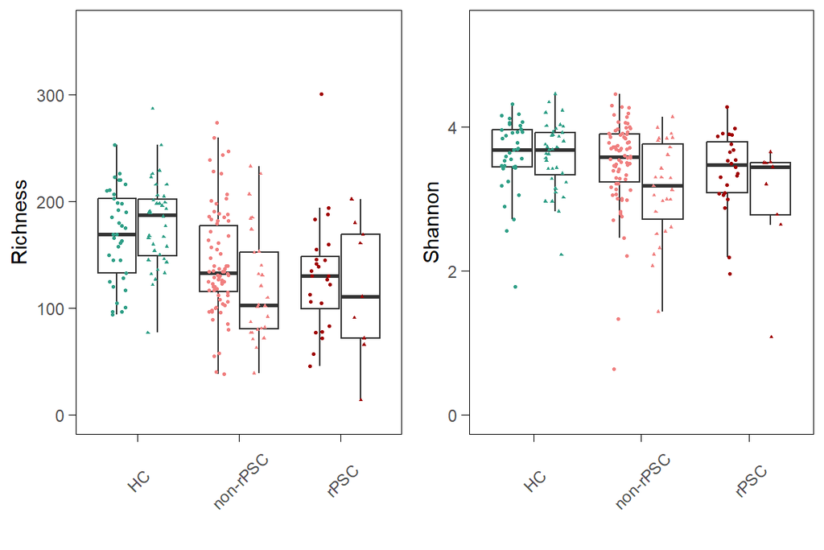

```r
p_boxplot_alpha <- alpha_diversity_countries(alpha_data)
# save the results
alpha_div_plots[[paste(segment,"Country")]] <- p_boxplot_alpha

# see the results
p_boxplot_alpha
```

### 2.2.2 Linear models

```r
path = "../../../results/merged_sites/main_analysis/Q2/alpha_diversity"
alpha_data <- read.csv(file.path(path,paste0("alpha_indices_",segment,".csv")))
```

**Richness**

```r
results_model <- pairwise.lm(formula = "Observe ~ Group * Country",
                             factors=alpha_data$Group,
                             data=alpha_data)

# check interaction
if (!is.data.frame(results_model)){
  results_model_observe <- results_model[[1]]
  results_model_observe_emeans <- results_model[[2]]
} else {
  results_model_observe <- results_model
  results_model_observe_emeans <- NA
}

# save the results
pc_observed <- list();
pc_observed[[segment]] <- results_model_observe
```

```r
# see the results
knitr::kable(results_model_observe,digits = 3,
caption = "Raw results of linear model of richness estimation.")
```

Raw results of linear model of richness estimation.

|  | Estimate | Std..Error | t.value | Pr…t.. | p.adj | sig |
| --- | --- | --- | --- | --- | --- | --- |
| non-rPSC vs GrouprPSC | -12.199 | 11.972 | -1.019 | 0.310 | 0.349 |  |
| non-rPSC , rPSC - CZ vs NO | -21.486 | 11.452 | -1.876 | 0.063 | 0.141 |  |
| non-rPSC vs GrouprPSC:CountryNO | 9.347 | 23.088 | 0.405 | 0.686 | 0.686 |  |
| healthy vs GrouprPSC | -37.741 | 12.284 | -3.072 | 0.003 | 0.025 | * |
| healthy , rPSC - CZ vs NO | 11.203 | 10.973 | 1.021 | 0.310 | 0.349 |  |
| healthy vs GrouprPSC:CountryNO | -23.342 | 21.355 | -1.093 | 0.277 | 0.349 |  |
| healthy vs Groupnon-rPSC | -25.542 | 9.322 | -2.740 | 0.007 | 0.031 | * |
| healthy , non-rPSC - CZ vs NO | 11.203 | 10.933 | 1.025 | 0.307 | 0.349 |  |
| healthy vs Groupnon-rPSC:CountryNO | -32.689 | 15.108 | -2.164 | 0.032 | 0.096 |  |

```r
knitr::kable(results_model_observe_emeans,digits = 3,
caption = "Raw results of independent country analysis")
```

Raw results of independent country analysis

| contrast | Country | estimate | SE | df | t.ratio | p.value |
| --- | --- | --- | --- | --- | --- | --- |
| (non-rPSC) - healthy | CZ | -25.542 | 9.322 | 174 | -2.740 | 0.007 |
| (non-rPSC) - healthy | NO | -58.231 | 11.889 | 174 | -4.898 | 0.000 |

**Shannon**

```r
results_model <- pairwise.lm(formula = "Shannon ~ Group * Country",
                             factors=alpha_data$Group,
                             data=alpha_data)

# check interaction
if (!is.data.frame(results_model)){
  results_model_shannon <- results_model[[1]]
  results_model_shannon_emeans <- results_model[[2]]
} else {
  results_model_shannon <- results_model
  results_model_shannon_emeans <- NA
}

# save the results
pc_shannon <- list();
pc_shannon[[segment]] <- as.data.frame(results_model_shannon)
```

```r
# see the results
knitr::kable(results_model_shannon,digits = 3,
caption = "Raw results of linear model of Shannon estimation.")
```

Raw results of linear model of Shannon estimation.

|  | Estimate | Std..Error | t.value | Pr…t.. | p.adj | sig |
| --- | --- | --- | --- | --- | --- | --- |
| non-rPSC vs GrouprPSC | -0.102 | 0.146 | -0.696 | 0.487 | 0.731 |  |
| non-rPSC , rPSC - CZ vs NO | -0.349 | 0.140 | -2.500 | 0.014 | 0.123 |  |
| non-rPSC vs GrouprPSC:CountryNO | -0.006 | 0.281 | -0.021 | 0.983 | 0.983 |  |
| healthy vs GrouprPSC | -0.210 | 0.140 | -1.501 | 0.137 | 0.321 |  |
| healthy , rPSC - CZ vs NO | 0.005 | 0.125 | 0.043 | 0.966 | 0.983 |  |
| healthy vs GrouprPSC:CountryNO | -0.360 | 0.244 | -1.478 | 0.142 | 0.321 |  |
| healthy vs Groupnon-rPSC | -0.109 | 0.115 | -0.948 | 0.344 | 0.620 |  |
| healthy , non-rPSC - CZ vs NO | 0.005 | 0.135 | 0.040 | 0.968 | 0.983 |  |
| healthy vs Groupnon-rPSC:CountryNO | -0.354 | 0.186 | -1.905 | 0.058 | 0.263 |  |

```r
knitr::kable(results_model_shannon_emeans,digits = 3,
caption = "Raw results of independent country analysis")
```

Raw results of independent country analysis

| contrast | Country | estimate | SE | df | t.ratio | p.value |
| --- | --- | --- | --- | --- | --- | --- |
| (non-rPSC) - healthy | CZ | -0.109 | 0.115 | 174 | -0.948 | 0.344 |
| (non-rPSC) - healthy | NO | -0.463 | 0.146 | 174 | -3.164 | 0.002 |

**Simpson**

```r
results_model <- pairwise.lm(formula = "Simpson ~ Group * Country",
                                     factors=alpha_data$Group,
                                     data=alpha_data)

# check interaction
if (!is.data.frame(results_model)){
  results_model_simpson <- results_model[[1]]
  results_model_simpson_emeans <- results_model[[2]]
} else {
  results_model_simpson <- results_model
  results_model_simpson_emeans <- NA
}

# save the results
pc_simpson <- list();
pc_simpson[[segment]] <- as.data.frame(results_model_simpson)
```

```r
# see the results
knitr::kable(results_model_simpson,digits = 3,
caption = "Raw results of linear model of Simpson estimation.")
```

Raw results of linear model of Simpson estimation.

|  | Estimate | Std..Error | t.value | Pr…t.. | p.adj | sig |
| --- | --- | --- | --- | --- | --- | --- |
| non-rPSC vs GrouprPSC | 0.000 | 0.023 | 0.019 | 0.985 | 0.985 |  |
| non-rPSC , rPSC - CZ vs NO | -0.034 | 0.022 | -1.573 | 0.118 | 0.531 |  |
| non-rPSC vs GrouprPSC:CountryNO | -0.029 | 0.043 | -0.661 | 0.510 | 0.767 |  |
| healthy vs GrouprPSC | -0.009 | 0.018 | -0.500 | 0.618 | 0.767 |  |
| healthy , rPSC - CZ vs NO | -0.008 | 0.016 | -0.501 | 0.617 | 0.767 |  |
| healthy vs GrouprPSC:CountryNO | -0.055 | 0.031 | -1.779 | 0.078 | 0.531 |  |
| healthy vs Groupnon-rPSC | -0.009 | 0.016 | -0.564 | 0.574 | 0.767 |  |
| healthy , non-rPSC - CZ vs NO | -0.008 | 0.019 | -0.410 | 0.682 | 0.767 |  |
| healthy vs Groupnon-rPSC:CountryNO | -0.026 | 0.027 | -0.975 | 0.331 | 0.767 |  |

```r
knitr::kable(results_model_simpson_emeans,digits = 3,
caption = "Raw results of independent country analysis")
```

Raw results of independent country analysis

| contrast | Country | estimate | SE | df | t.ratio | p.value |
| --- | --- | --- | --- | --- | --- | --- |
| rPSC - healthy | CZ | -0.009 | 0.018 | 102 | -0.500 | 0.618 |
| rPSC - healthy | NO | -0.064 | 0.025 | 102 | -2.526 | 0.013 |

**Pielou**

```r
results_model <- pairwise.lm(formula = "Pielou ~ Group * Country",
                                     factors=alpha_data$Group,
                                     data=alpha_data)

# check interaction

if (!is.data.frame(results_model)){
  results_model_pielou <- results_model[[1]]
  results_model_pielou_emeans <- results_model[[2]]
} else {
  results_model_pielou <- results_model
  results_model_pielou_emeans <- NA
}

# save the results
pc_pielou <- list();
pc_pielou[[segment]] <- as.data.frame(results_model_pielou)
```

```r
# see the results
knitr::kable(results_model_pielou,digits = 3,
caption = "Raw results of linear model of Pielou estimation.")
```

Raw results of linear model of Pielou estimation.

|  | Estimate | Std..Error | t.value | Pr…t.. | p.adj | sig |
| --- | --- | --- | --- | --- | --- | --- |
| non-rPSC vs GrouprPSC | -0.004 | 0.022 | -0.184 | 0.854 | 0.946 |  |
| non-rPSC , rPSC - CZ vs NO | -0.047 | 0.021 | -2.260 | 0.025 | 0.229 |  |
| non-rPSC vs GrouprPSC:CountryNO | -0.005 | 0.042 | -0.108 | 0.914 | 0.946 |  |
| healthy vs GrouprPSC | -0.001 | 0.021 | -0.067 | 0.946 | 0.946 |  |
| healthy , rPSC - CZ vs NO | -0.009 | 0.018 | -0.463 | 0.645 | 0.946 |  |
| healthy vs GrouprPSC:CountryNO | -0.043 | 0.036 | -1.195 | 0.235 | 0.705 |  |
| healthy vs Groupnon-rPSC | 0.003 | 0.018 | 0.146 | 0.884 | 0.946 |  |
| healthy , non-rPSC - CZ vs NO | -0.009 | 0.021 | -0.409 | 0.683 | 0.946 |  |
| healthy vs Groupnon-rPSC:CountryNO | -0.038 | 0.029 | -1.329 | 0.185 | 0.705 |  |

```r
knitr::kable(results_model_pielou_emeans,digits = 3,
caption = "Raw results of independent country analysis")
```

Table: Raw results of independent country analysis

### 2.2.3 Saving results

```r
alpha_list <- list(
  Richness=pc_observed[[segment]] %>% rownames_to_column("Comparison"),
  Shannon=pc_shannon[[segment]] %>% rownames_to_column("Comparison"),
  Simpson=pc_simpson[[segment]] %>% rownames_to_column("Comparison"),
  Pielou=pc_pielou[[segment]] %>% rownames_to_column("Comparison"))

write.xlsx(alpha_list,
           file = file.path(path,paste0("alpha_diversity_results_",segment,".xlsx")))
```

## 2.3 Beta diversity

Calculating Aitchison distance (euclidean distance on clr-transformed data), both at ASV and genus level.

### 2.3.1 Main analysis

**Genus level, Aitchison distance**

```r
level="genus"
path = "../../../results/merged_sites/main_analysis/Q2/beta_diversity"

pairwise_aitchison_raw <- list()
pca_plots_list <- list()
```

Aggregation, filtering

```r
# Aggregation
genus_data <- aggregate_taxa(ileum_asv_tab,
                             ileum_taxa_tab,
                             taxonomic_level=level,
                             names=TRUE)
# Filtration
filt_data <- filtering_steps(genus_data[[1]],
                             genus_data[[2]],
                             ileum_metadata,
                             seq_depth_threshold=10000)
```

```
Removing 2 ASV(s)
```

```r
filt_ileum_genus_tab <- filt_data[[1]]
filt_ileum_genus_taxa <- filt_data[[2]]
filt_ileum_metadata <- filt_data[[3]]
```

##### 2.3.1.0.1 PERMANOVA

```r
pairwise_df <- filt_ileum_genus_tab %>% column_to_rownames("SeqID") %>% t()

# main effect
pp_main <- pairwise.adonis(pairwise_df,
                           filt_ileum_metadata$Group,
                           covariate = filt_ileum_metadata$Country, sim.method = "robust.aitchison", p.adjust.m="BH")

# interaction
pp_int <- pairwise.adonis(pairwise_df,filt_ileum_metadata$Group,covariate = filt_ileum_metadata$Country, interaction = TRUE, sim.method = "robust.aitchison", p.adjust.m="BH")

# tidy the results
pp_factor <- pp_main[[1]]
pp_cov <- pp_main[[2]]
pp_fac.cov <- pp_int[[3]]

cols <- c("pairs","Df","SumsOfSqs", "F.Model","R2","p.value", "p.adjusted", "sig")
colnames(pp_factor) <- cols; colnames(pp_cov) <- cols; colnames(pp_fac.cov) <- cols;

# save raw results
pairwise_aitchison_raw[[paste(level, segment)]] <- rbind(pp_factor,pp_cov,pp_fac.cov)
```

```r
# see the results
knitr::kable(pp_factor,digits = 3,caption = "PERMANOVA, GROUP separation")
```

PERMANOVA, GROUP separation

| pairs | Df | SumsOfSqs | F.Model | R2 | p.value | p.adjusted | sig |
| --- | --- | --- | --- | --- | --- | --- | --- |
| rPSC vs non-rPSC | 1 | 215.579 | 1.208 | 0.009 | 0.107 | 0.107 |  |
| rPSC vs healthy | 1 | 561.696 | 3.345 | 0.030 | 0.001 | 0.002 | ** |
| non-rPSC vs healthy | 1 | 760.242 | 4.431 | 0.024 | 0.001 | 0.002 | ** |

```r
knitr::kable(pp_cov,digits = 3,caption = "PERMANOVA, COUNTRY separation")
```

PERMANOVA, COUNTRY separation

| pairs | Df | SumsOfSqs | F.Model | R2 | p.value | p.adjusted | sig |
| --- | --- | --- | --- | --- | --- | --- | --- |
| rPSC vs non-rPSC , Country | 1 | 601.929 | 3.372 | 0.024 | 0.001 | 0.001 | *** |
| rPSC vs healthy , Country | 1 | 496.841 | 2.959 | 0.027 | 0.001 | 0.001 | *** |
| non-rPSC vs healthy , Country | 1 | 624.474 | 3.640 | 0.020 | 0.001 | 0.001 | *** |

```r
knitr::kable(pp_fac.cov,digits = 3,caption = "PERMANOVA, INTERACTION GROUP:Country")
```

PERMANOVA, INTERACTION GROUP:Country

| pairs | Df | SumsOfSqs | F.Model | R2 | p.value | p.adjusted | sig |
| --- | --- | --- | --- | --- | --- | --- | --- |
| rPSC vs non-rPSC : Country | 1 | 156.176 | 0.874 | 0.006 | 0.788 | 0.788 |  |
| rPSC vs healthy : Country | 1 | 164.743 | 0.981 | 0.009 | 0.464 | 0.696 |  |
| non-rPSC vs healthy : Country | 1 | 209.954 | 1.225 | 0.007 | 0.089 | 0.267 |  |

Interaction check

```r
interaction_sig <- pp_fac.cov$pairs[pp_fac.cov$p.adjusted < 0.05]

if (length(interaction_sig)>0){
  for (i in 1:length(interaction_sig)){
  group1 <- unlist(strsplit(interaction_sig[i],split = " vs "))[1]
  group2 <- unlist(strsplit(interaction_sig[i],split = " vs "))[2]
  group2 <- unlist(strsplit(group2,split = " : "))[1]

  result_list <- adonis_postanalysis(x=pairwise_df,
                      factors = filt_ileum_metadata$Group,
                      covariate = filt_ileum_metadata$Country,
                      group1 = group1,
                      group2 = group2)
  print(result_list)
}
}
```

##### 2.3.1.0.2 Plots

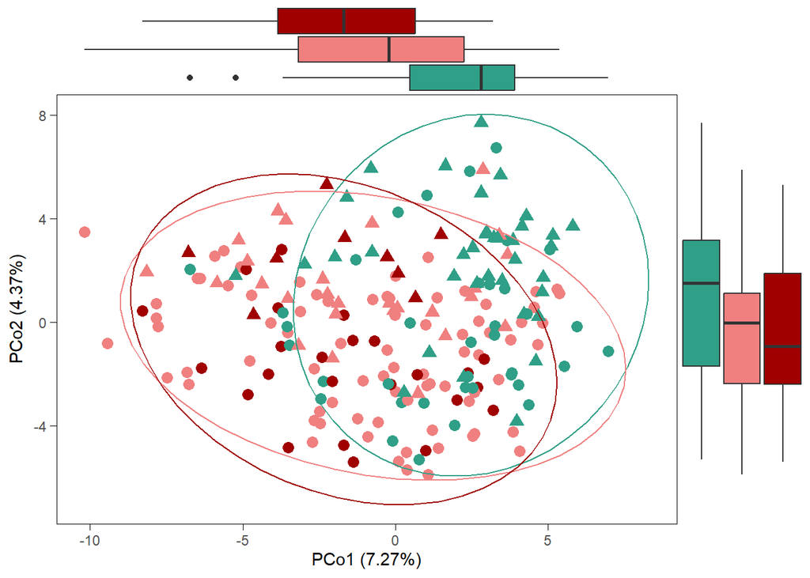

```r
p <- pca_plot_custom(filt_ileum_genus_tab,
                                 filt_ileum_genus_taxa,
                                 filt_ileum_metadata,
                                 show_boxplots = TRUE,
                                 variable = "Group", size=3, show_legend=FALSE)

# save the results
pca_plots_list[[paste(segment,level,"custom")]] <- p

# see the results
p
```

#### 2.3.1.1 Saving results

```r
write.xlsx(pairwise_aitchison_raw[[paste(level, segment)]],
           file = file.path(path,
           paste0("beta_diversity_results_", segment,".xlsx")))
```

## 2.4 Univariate Analysis

### 2.4.1 Main analysis

```r
level="genus"

# needed paths
path = "../../../results/merged_sites/main_analysis/Q2/univariate_analysis"
path_maaslin=file.path("../../../intermediate_files/maaslin/Q2",level)

# variables
raw_linda_results_genus <- list();
raw_linda_results_genus[[segment]] <- list()
linda_results_genus <- list();
linda_results_genus[[segment]] <- list()

# country and interaction problems
list_country_union <- list()
list_intersections <- list()
list_venns <- list()
uni_statistics <- list()

# workbook for final df
wb <- createWorkbook()

# rPSC effect
rpsc_effect <- list()
```

Aggregate taxa

```r
genus_data <- aggregate_taxa(ileum_asv_tab,
                             ileum_taxa_tab,
                             taxonomic_level = level)

ileum_genus_tab <- genus_data[[1]]
ileum_genus_taxa_tab <- genus_data[[2]]

ileum_genus_asv_taxa_tab <- create_asv_taxa_table(ileum_genus_tab,
                                                  ileum_genus_taxa_tab)
```

#### 2.4.1.1 rPSC vs non-rPSC

```r
group <- c("non-rPSC","rPSC")
comparison_name <- paste0(group[1], " vs ",group[2])
```

##### 2.4.1.1.1 linDA

```r
taxa_to_test <- read.xlsx("../../../results/merged_sites/main_analysis/Q1/univariate_analysis/significant_taxa_terminal_ileum.xlsx", sheet=" genus healthy vs pre_ltx")$SeqID

ileum_genus_tab_2 <- ileum_genus_tab %>% dplyr::filter(SeqID %in% taxa_to_test)
ileum_genus_taxa_tab_2 <- ileum_genus_taxa_tab %>% dplyr::filter(SeqID %in% taxa_to_test)

# prepare the data
linda_data <- binomial_prep(ileum_genus_tab_2,
                            ileum_genus_taxa_tab_2,
                            ileum_metadata,
                            group, usage="linDA", filtering = FALSE)

filt_ileum_uni_data <- linda_data[[1]]
filt_ileum_uni_taxa <- linda_data[[2]]
filt_ileum_uni_metadata <- linda_data[[3]]

# fit the model
linda.obj <- linda(filt_ileum_uni_data,
                   filt_ileum_uni_metadata,
                   formula = '~ Group * Country')
```

[output not shown]

```r
linda.output <- linda.obj$output
linda.output <- linda_renaming(linda.output, group)

# save the results
group1 <- paste0(group[1], " vs ","Group",group[2])
group2 <- paste0(group[1], " , ",group[2], " - CZ vs NO")
group3 <- paste0(group[1], " vs ","Group",group[2], ":CountryNO")

for (grp in c(group1,group2,group3)){
  raw_linda_results_genus[[segment]][[grp]] <-
    rawlinda.df(linda.output,
                grp,
                filt_ileum_uni_data,
                filt_ileum_uni_taxa)

  linda_results_genus[[segment]][[grp]] <-
    linda.df(linda.output,
             grp,
             filt_ileum_uni_data,
             filt_ileum_uni_taxa)
}
```

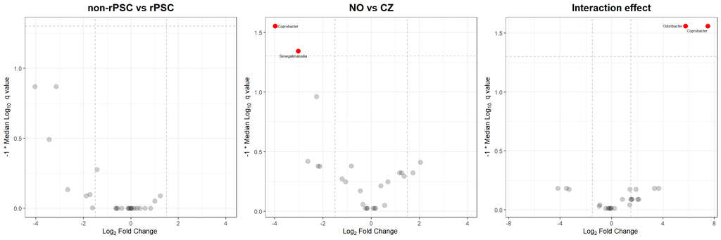

```r
# volcano plot
volcano_1 <- volcano_plot_linda(linda.output,
                                group1,
                                taxa_table = filt_ileum_uni_taxa) +
            ggtitle(comparison_title)

volcano_2  <- volcano_plot_linda(linda.output, group2,
                                taxa_table = filt_ileum_uni_taxa) +
            ggtitle("NO vs CZ")

volcano_3 <- volcano_plot_linda(linda.output, group3,
                                taxa_table = filt_ileum_uni_taxa) +
            ggtitle("Interaction effect")

volcano <- ggarrange(volcano_1,volcano_2,volcano_3, ncol=3)
volcano
```

##### 2.4.1.1.2 MaAsLin2

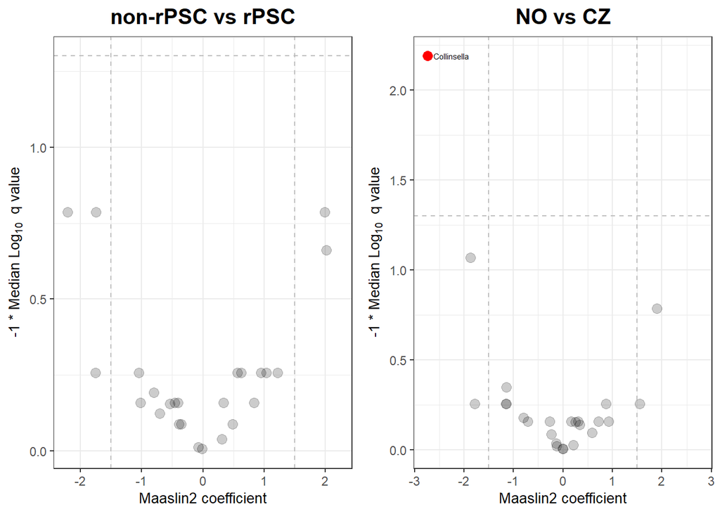

```r
volcano1 <- volcano_plot_maaslin(fit_data,filt_ileum_uni_taxa) +
            ggtitle(comparison_title)

volcano2 <- volcano_plot_maaslin(fit_data,filt_ileum_uni_taxa,variable="Country") +
            ggtitle("NO vs CZ")

volcano <- ggarrange(volcano1,volcano2, ncol=2)

volcano
```

##### 2.4.1.1.3 Group - Intersection

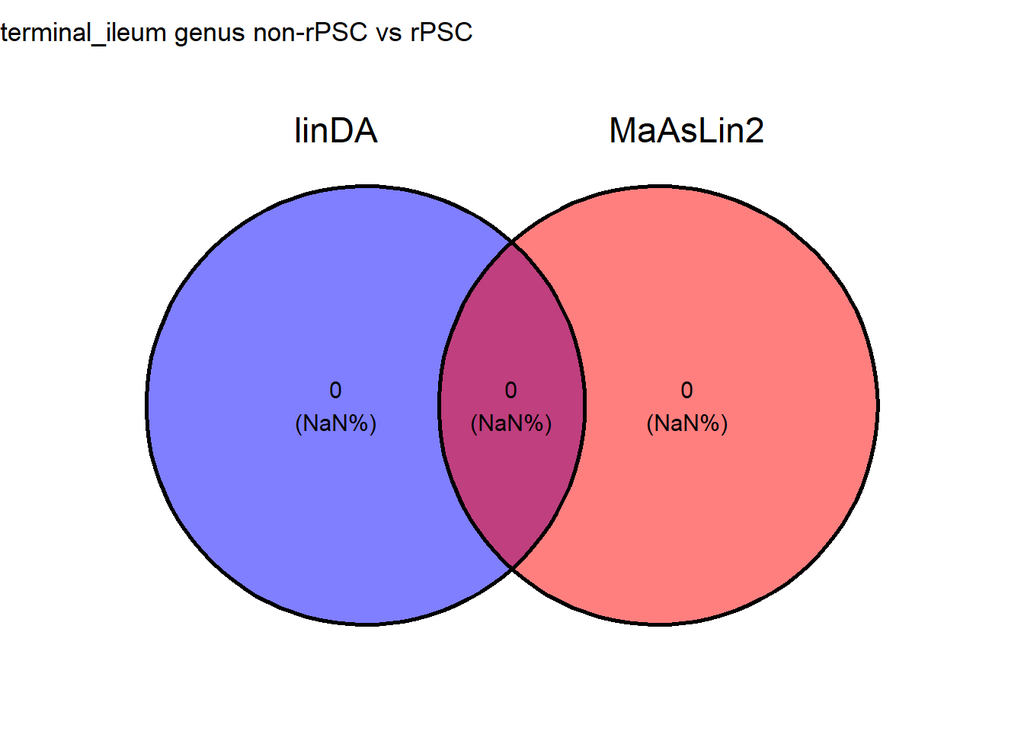

```r
intersection_results <- group_intersection(group, list_intersections, list_venns,
                                           linda.output, fit_data,
                                           raw_linda_results_genus,
                                           segment = segment,
                                           level=level)

list_intersections <- intersection_results[[1]]
list_venns <- intersection_results[[2]]
venn <- intersection_results[[3]]

# show the results
venn
```

##### 2.4.1.1.4 Interaction effect

```r
list_interaction_significant <- country_interaction(group,
                                                    linda.output,
                                                    list_intersections,
                                          filt_ileum_uni_data,
                                          filt_ileum_uni_metadata,
                                          segment=segment,
                                          level=level)

# see the result
## significant interaction effect
list_interaction_significant[[1]]
```

```r
## results for czech cohort
list_interaction_significant[[2]]
```

```
[1] NA
```

```r
## results for norwegian cohort
list_interaction_significant[[3]]
```

```
[1] NA
```

Removing problematic taxa

```r
list_intersections <- removing_interaction_problems(group,
                                                    list_interaction_significant,
                                                    list_intersections,
                                                    segment=segment,
                                                    level=level)
```

##### 2.4.1.1.5 Basic statistics

```r
uni_df <-  merge(basic_univariate_statistics(linda_data,group),
                 raw_linda_results_genus[[segment]][[group1]],
                 by="SeqID",all=TRUE)
```

```
[1] "non-rPSC"
[1] "rPSC"
[1] "non-rPSC"
[1] "rPSC"
```

```r
uni_df[["final_sig"]] <- uni_df$SeqID %in% list_intersections[[paste(segment,level,comparison_name)]][["SeqID"]]
uni_statistics[[segment]][[paste(level,comparison_name)]] <- uni_df

# for comparison
new_name <- comparison_name
addWorksheet(wb, sheetName = new_name)
writeData(wb, sheet = new_name, uni_df, rowNames=FALSE)
```

##### 2.4.1.1.6 Prevalence testing

```r
uni_df$prevalence_diff <- abs(uni_df$`PREVALENCE_ rPSC` - uni_df$`PREVALENCE_ non-rPSC`)

#uni_df %<>% dplyr::filter(prevalence_diff >=0.2)
#filt_colon_uni_data <- filt_colon_uni_data[uni_df$SeqID,]
filt_ileum_uni_data <- ifelse(filt_ileum_uni_data>0,"YES","NO")
filt_ileum_uni_data %<>% t() %>% as.data.frame()
#filt_colon_uni_taxa %<>% dplyr::filter(SeqID %in% uni_df$SeqID)

filt_ileum_uni_data <- merge(filt_ileum_uni_data %>% rownames_to_column("SampleID"),filt_ileum_metadata,by="SampleID",all.x=TRUE) %>% column_to_rownames("SampleID")

p_values <- c()
for (taxon in uni_df$SeqID){
data <- filt_ileum_uni_data %>%
  group_by(!!sym(taxon), Group) %>%
  count() %>%
  group_by(!!sym(taxon), Group) %>%
  summarise(n = sum(n), .groups = "drop") %>%
  pivot_wider(names_from = Group, values_from = n) %>%
  column_to_rownames(taxon) %>%
  as.matrix()

if (nrow(data)>1){
  data[is.na(data)] <- 0
chi_res <- chisq.test(data)
chi_res$expected
#p_values <- c(p_values,chi_res$p.value)

test <- fisher.test(data)
test$p.value
p_values <- c(p_values,test$p.value)
} else p_values <- c(p_values,NA)

}
p_values_adjusted <- p.adjust(p_values,method = "BH")
names(p_values_adjusted) <- uni_df$SeqID
names(p_values) <- uni_df$SeqID
p_values_adjusted[which(p_values_adjusted<0.05)]
```

```
named numeric(0)
```

```r
asv_tab <- as.data.frame(rrarefy(
    linda_data[[1]] %>% t(),
    sample=10000)) %>% t() %>% as.data.frame()

asv_tab <- ifelse(asv_tab>10,"YES","NO")
asv_tab %<>% t() %>% as.data.frame()

asv_tab <- merge(asv_tab %>% rownames_to_column("SampleID"),filt_ileum_metadata,by="SampleID",all.x=TRUE) %>% column_to_rownames("SampleID")

p_values <- c()
for (taxon in uni_df$SeqID){
data <- asv_tab %>%
  group_by(!!sym(taxon), Group) %>%
  count() %>%
  group_by(!!sym(taxon), Group) %>%
  summarise(n = sum(n), .groups = "drop") %>%
  pivot_wider(names_from = Group, values_from = n) %>%
  column_to_rownames(taxon) %>%
  as.matrix()

if (nrow(data)>1){
data[is.na(data)] <- 0
chi_res <- chisq.test(data)
chi_res$expected
test <- fisher.test(data)
test$p.value
chi_res$p.value
p_values <- c(p_values,test$p.value)
} else p_values <- c(p_values,NA)
}
p_values_adjusted <- p.adjust(p_values,method = "BH")
names(p_values_adjusted) <- uni_df$SeqID
names(p_values) <- uni_df$SeqID
p_values_adjusted[which(p_values_adjusted<0.05)]
```

```
named numeric(0)
```

```r
df <- data.frame(SeqID=uni_df$SeqID,
                 p=p_values,
                 p_adj=p_values_adjusted)
```

```r
prevalence_df <- uni_df[,c("SeqID","PREVALENCE_ non-rPSC","PREVALENCE_ rPSC")]
prevalence_df <- merge(prevalence_df,df,by="SeqID",all=TRUE)
write.xlsx(prevalence_df,file.path(path,paste0("supplements_prevalence_",segment,".xlsx")))
```

#### 2.4.1.2 rPSC vs healthy

```r
group <- c("healthy","rPSC")
comparison_name <- paste0(group[1], " vs ",group[2])
```

##### 2.4.1.2.1 linDA

```r
# prepare the data
linda_data <- binomial_prep(ileum_genus_tab,
                            ileum_genus_taxa_tab,
                            ileum_metadata,
                            group, usage="linDA")
```

```
Removing 67 ASV(s)
```

```
Removing 4 ASV(s)
```

```r
filt_ileum_uni_data <- linda_data[[1]]
filt_ileum_uni_taxa <- linda_data[[2]]
filt_ileum_uni_metadata <- linda_data[[3]]

# fit the model
linda.obj <- linda(filt_ileum_uni_data,
                   filt_ileum_uni_metadata,
                   formula = '~ Group * Country')
```

```
0  features are filtered!
The filtered data has  106  samples and  207  features will be tested!
Imputation approach is used.
Fit linear models ...
Completed.
```

```r
linda.output <- linda.obj$output
linda.output <- linda_renaming(linda.output, group)

# save the results
group1 <- paste0(group[1], " vs ","Group",group[2])
group2 <- paste0(group[1], " , ",group[2], " - CZ vs NO")
group3 <- paste0(group[1], " vs ","Group",group[2], ":CountryNO")

for (grp in c(group1,group2,group3)){
  raw_linda_results_genus[[segment]][[grp]] <-
    rawlinda.df(linda.output,
                grp,
                filt_ileum_uni_data,
                filt_ileum_uni_taxa)

  linda_results_genus[[segment]][[grp]] <-
    linda.df(linda.output,
             grp,
             filt_ileum_uni_data,
             filt_ileum_uni_taxa)
}
```

```r
# volcano plot
volcano_1 <- volcano_plot_linda(linda.output,
                                group1,
                                taxa_table = filt_ileum_uni_taxa) +
            ggtitle(comparison_title)

volcano_2  <- volcano_plot_linda(linda.output, group2,
                                taxa_table = filt_ileum_uni_taxa) +
            ggtitle("NO vs CZ")

volcano_3 <- volcano_plot_linda(linda.output, group3,
                                taxa_table = filt_ileum_uni_taxa) +
            ggtitle("Interaction effect")

volcano <- ggarrange(volcano_1,volcano_2,volcano_3, ncol=3)
```

##### 2.4.1.2.2 MaAsLin2

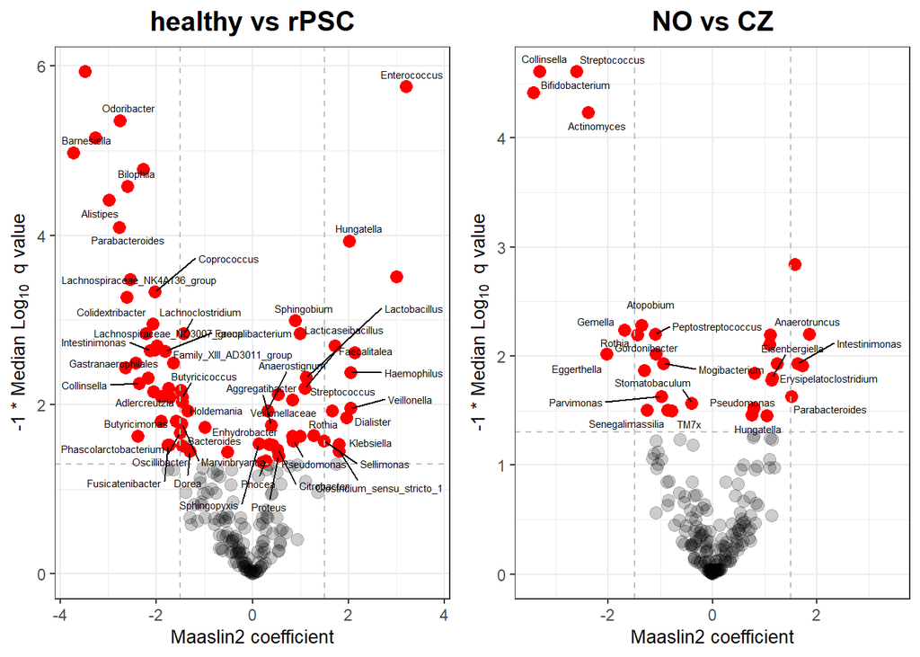

```r
volcano1 <- volcano_plot_maaslin(fit_data,filt_ileum_uni_taxa) +
            ggtitle(comparison_title)

volcano2 <- volcano_plot_maaslin(fit_data,filt_ileum_uni_taxa,variable="Country") +
            ggtitle("NO vs CZ")

volcano <- ggarrange(volcano1,volcano2, ncol=2)
volcano
```

##### 2.4.1.2.3 Group - Intersection

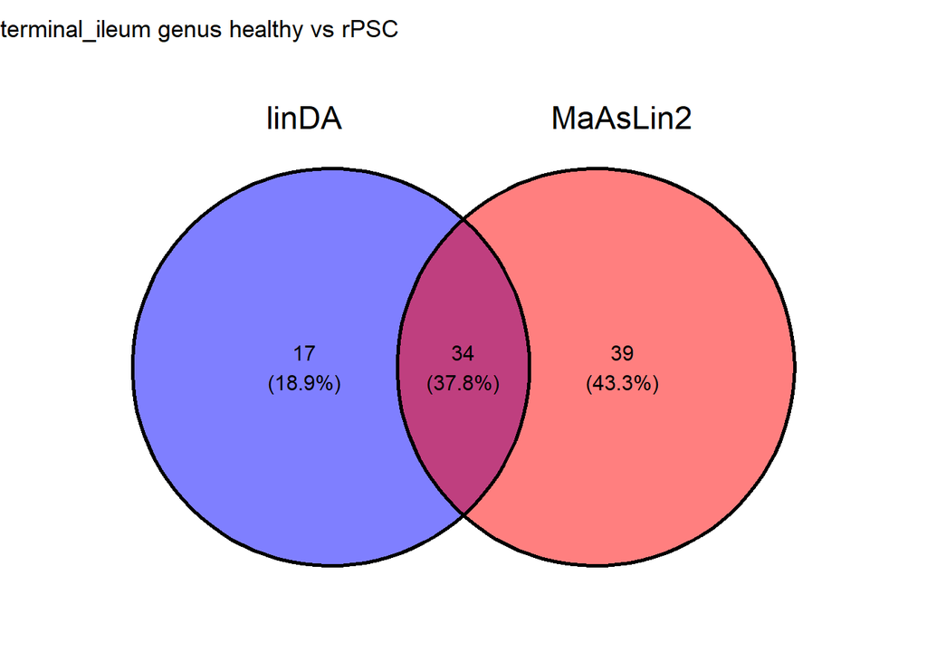

```r
intersection_results <- group_intersection(group, list_intersections, list_venns,
                                           linda.output, fit_data,
                                           raw_linda_results_genus,
                                           segment = segment,
                                           level=level)

list_intersections <- intersection_results[[1]]
list_venns <- intersection_results[[2]]
venn <- intersection_results[[3]]

# show the results
venn
```

##### 2.4.1.2.4 Interaction effect

```r
list_interaction_significant <- country_interaction(group,
                                                    linda.output,
                                                    list_intersections,
                                          filt_ileum_uni_data,
                                          filt_ileum_uni_metadata,
                                          segment=segment,
                                          level=level)

# see the result
## significant interaction effect
list_interaction_significant[[1]]
```

```r
## results for czech cohort
list_interaction_significant[[2]]
```

```
[1] NA
```

```r
## results for norwegian cohort
list_interaction_significant[[3]]
```

```
[1] NA
```

Removing problematic taxa

```r
list_intersections <- removing_interaction_problems(group,
                                                    list_interaction_significant,
                                                    list_intersections,
                                                    segment=segment,
                                                    level=level)
```

##### 2.4.1.2.5 Basic statistics

```r
uni_df <-  merge(basic_univariate_statistics(linda_data,group),
                 raw_linda_results_genus[[segment]][[group1]],
                 by="SeqID",all=TRUE)
```

```
[1] "healthy"
[1] "rPSC"
[1] "healthy"
[1] "rPSC"
```

```r
uni_df[["final_sig"]] <- uni_df$SeqID %in% list_intersections[[paste(segment,level,comparison_name)]][["SeqID"]]
uni_statistics[[segment]][[paste(level,comparison_name)]] <- uni_df

# for comparison
new_name <- comparison_name
addWorksheet(wb, sheetName = new_name)
writeData(wb, sheet = new_name, uni_df, rowNames=FALSE)
```

#### 2.4.1.3 non-rPSC vs healthy

```r
group <- c("healthy","non-rPSC")
comparison_name <- paste0(group[1], " vs ",group[2])
```

##### 2.4.1.3.1 linDA

```r
# prepare the data
linda_data <- binomial_prep(ileum_genus_tab,
                            ileum_genus_taxa_tab,
                            ileum_metadata,
                            group, usage="linDA")
```

```
Removing 24 ASV(s)
```

```
Removing 2 ASV(s)
```

```r
filt_ileum_uni_data <- linda_data[[1]]
filt_ileum_uni_taxa <- linda_data[[2]]
filt_ileum_uni_metadata <- linda_data[[3]]

# fit the model
linda.obj <- linda(filt_ileum_uni_data,
                   filt_ileum_uni_metadata,
                   formula = '~ Group * Country')
```

```
0  features are filtered!
The filtered data has  178  samples and  179  features will be tested!
Imputation approach is used.
Fit linear models ...
Completed.
```

```r
linda.output <- linda.obj$output
linda.output <- linda_renaming(linda.output, group)

# save the results
group1 <- paste0(group[1], " vs ","Group",group[2])
group2 <- paste0(group[1], " , ",group[2], " - CZ vs NO")
group3 <- paste0(group[1], " vs ","Group",group[2], ":CountryNO")

for (grp in c(group1,group2,group3)){
  raw_linda_results_genus[[segment]][[grp]] <-
    rawlinda.df(linda.output,
                grp,
                filt_ileum_uni_data,
                filt_ileum_uni_taxa)

  linda_results_genus[[segment]][[grp]] <-
    linda.df(linda.output,
             grp,
             filt_ileum_uni_data,
             filt_ileum_uni_taxa)
}
```

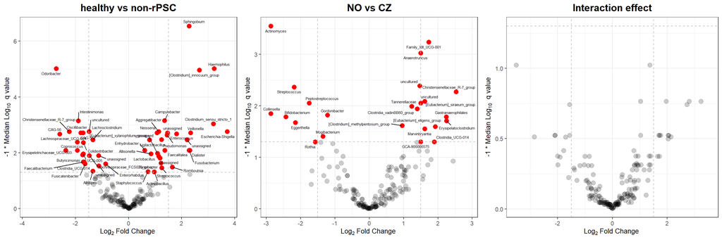

```r
# volcano plot
volcano_1 <- volcano_plot_linda(linda.output,
                                group1,
                                taxa_table = filt_ileum_uni_taxa) +
            ggtitle(comparison_title)

volcano_2  <- volcano_plot_linda(linda.output, group2,
                                taxa_table = filt_ileum_uni_taxa) +
            ggtitle("NO vs CZ")

volcano_3 <- volcano_plot_linda(linda.output, group3,
                                taxa_table = filt_ileum_uni_taxa) +
            ggtitle("Interaction effect")

volcano <- ggarrange(volcano_1,volcano_2,volcano_3, ncol=3)
volcano
```

##### 2.4.1.3.2 MaAsLin2

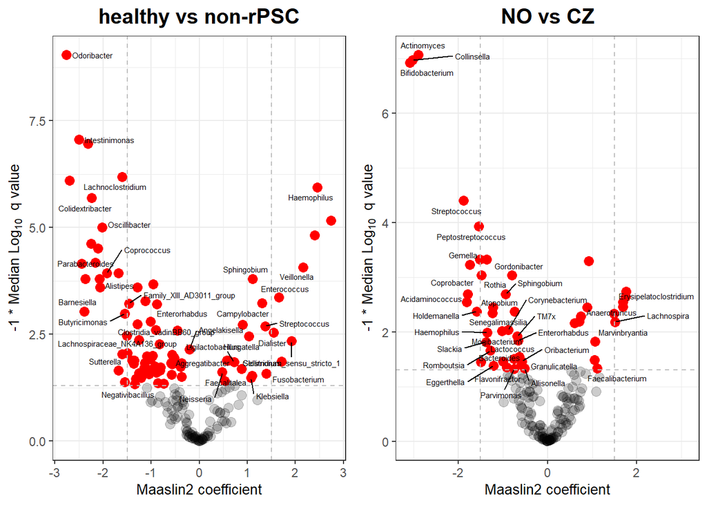

```r
volcano1 <- volcano_plot_maaslin(fit_data,filt_ileum_uni_taxa) +
            ggtitle(comparison_title)

volcano2 <- volcano_plot_maaslin(fit_data,filt_ileum_uni_taxa,variable="Country") +
            ggtitle("NO vs CZ")

volcano <- ggarrange(volcano1,volcano2, ncol=2)
volcano
```

##### 2.4.1.3.3 Group - Intersection

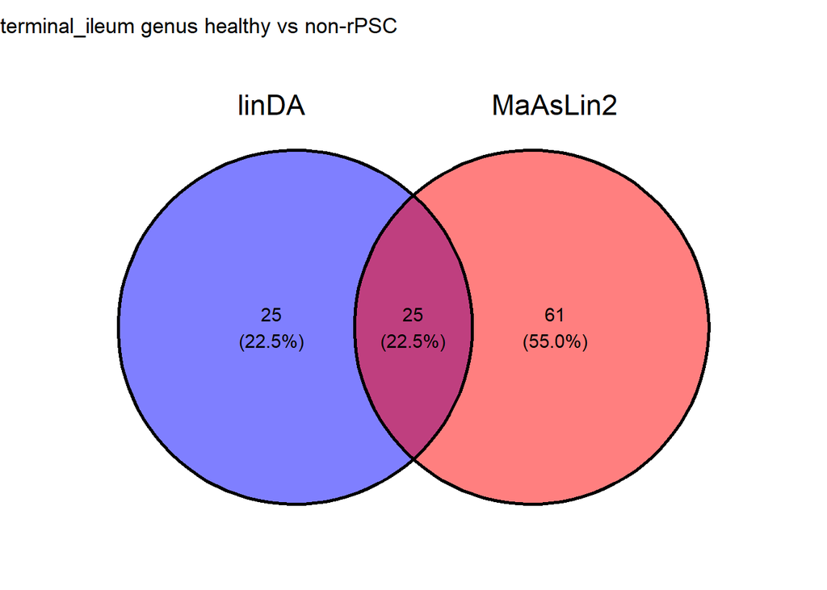

```r
intersection_results <- group_intersection(group, list_intersections, list_venns,
                                           linda.output, fit_data,
                                           raw_linda_results_genus,
                                           segment = segment,
                                           level=level)

list_intersections <- intersection_results[[1]]
list_venns <- intersection_results[[2]]
venn <- intersection_results[[3]]

# show the results
venn
```

##### 2.4.1.3.4 Interaction effect

```r
list_interaction_significant <- country_interaction(group,
                                                    linda.output,
                                                    list_intersections,
                                          filt_ileum_uni_data,
                                          filt_ileum_uni_metadata,
                                          segment=segment,
                                          level=level)

# see the result
## significant interaction effect
list_interaction_significant[[1]]
```

```r
## results for czech cohort
list_interaction_significant[[2]]
```

```
[1] NA
```

```r
## results for norwegian cohort
list_interaction_significant[[3]]
```

```
[1] NA
```

Removing problematic taxa

```r
list_intersections <- removing_interaction_problems(group,
                                                    list_interaction_significant,
                                                    list_intersections,
                                                    segment=segment,
                                                    level=level)
```

##### 2.4.1.3.5 Basic statistics

```r
uni_df <-  merge(basic_univariate_statistics(linda_data,group),
                 raw_linda_results_genus[[segment]][[group1]],
                 by="SeqID",all=TRUE)
```

```
[1] "healthy"
[1] "non-rPSC"
[1] "healthy"
[1] "non-rPSC"
```

```r
uni_df[["final_sig"]] <- uni_df$SeqID %in% list_intersections[[paste(segment,level,comparison_name)]][["SeqID"]]
uni_statistics[[segment]][[paste(level,comparison_name)]] <- uni_df

# for comparison
new_name <- comparison_name
addWorksheet(wb, sheetName = new_name)
writeData(wb, sheet = new_name, uni_df, rowNames=FALSE)
```

#### 2.4.1.4 Visualization

Heatmap visualizing the linDA’s logFoldChange for taxa with p < 0.1.

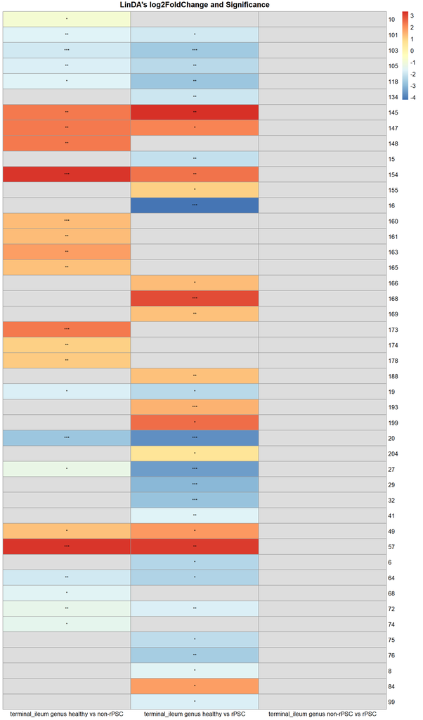

```r
list_heatmap <- list_intersections[grep(paste(segment,level),
                                  names(list_intersections),value=TRUE)]

p_heatmap_linda <- heatmap_linda(list_heatmap,ileum_taxa_tab)
p_heatmap_linda
```

**Dot heatmap**

```r
dotheatmap_linda <- dot_heatmap_linda(
  list_heatmap,                               uni_statistics$terminal_ileum[grepl(level,names(uni_statistics$terminal_ileum))],
                                      ileum_taxa_tab) + xlab("") + ylab("")
```

```
min_clr -1.727234
max_clr 7.029952
min_log -4.215042
max_log 3.331439
```

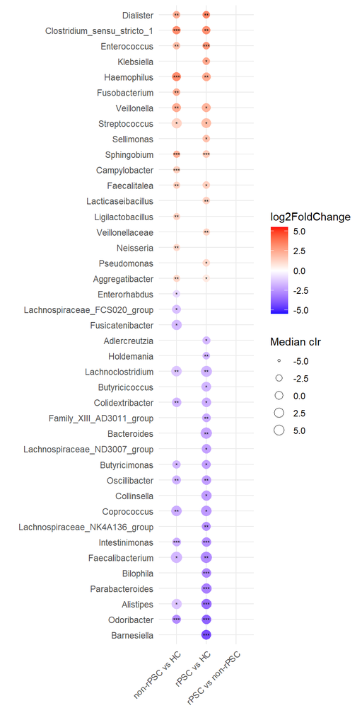

```r
dotheatmap_linda
```

**Horizontal bar plot**

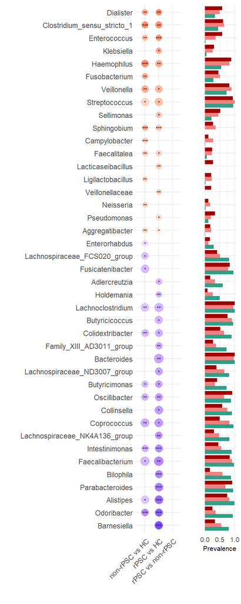

```r
p_prevalence <- horizontal_barplot(wb,taxa=levels(dotheatmap_linda$data$SeqID))
p_prevalence_final <- ggarrange(p_prevalence,
                                ggplot() + theme_minimal(),
                                nrow = 2,heights = c(1,0.085))

p <- ggarrange(dotheatmap_linda + theme(legend.position = "none"),p_prevalence_final,ncol=2,widths = c(1,0.3))

p
```

```r
dot_heatmap_ileum <- p
```

#### 2.4.1.5 rPSC effect

```r
A <- list_intersections[[paste(segment,level,"healthy vs rPSC")]]
B <- list_intersections[[paste(segment,level,"healthy vs non-rPSC")]]
df <- A[!(A$SeqID %in% B$SeqID),]


rpsc_effect[[paste(segment,level)]] <- df

# see the results
rpsc_effect[[paste(segment,level)]]
```

```
                            SeqID
6                     Collinsella
8                   Adlercreutzia
15                    Bacteroides
16                    Barnesiella
29                Parabacteroides
32                      Bilophila
41                     Holdemania
75   Lachnospiraceae_ND3007_group
76  Lachnospiraceae_NK4A136_group
84                     Sellimonas
99                 Butyricicoccus
134      Family_XIII_AD3011_group
155                   Pseudomonas
169            Lacticaseibacillus
```

[output cut: 36 more lines]

#### 2.4.1.6 Saving results

```r
# ALL DATA
saveWorkbook(wb,file.path(path,paste0("uni_analysis_wb_",segment,".xlsx")),
             overwrite = TRUE)

# PSC effect
write.xlsx(rpsc_effect[[paste(segment,level)]],file.path(path,paste0("rpsc_effect_",segment,".xlsx")))

# SIGNIFICANT taxa

write.xlsx(list_intersections[grepl(segment,names(list_intersections))] %>%
            `names<-`(gsub(segment, "", names(
              list_intersections[grepl(segment,names(list_intersections))]))),
           file.path(path,paste0("significant_taxa_",segment,".xlsx")))
```

## 2.5 Machine learning

```r
path = "../../../results/merged_sites/main_analysis/Q2/models"
```

### 2.5.1 ElasticNet

```r
model="enet"
```

#### 2.5.1.1 Genus level

```r
level="genus"
```

Aggregate taxa

```r
genus_data <- aggregate_taxa(ileum_asv_tab,
                             ileum_taxa_tab,
                             taxonomic_level = level)

ileum_genus_tab <- genus_data[[1]]
ileum_genus_taxa_tab <- genus_data[[2]]
```

##### 2.5.1.1.1 rPSC vs non-rPSC - all

```r
group <- c("rPSC","non-rPSC")
comparison_name <- paste0(group[1], " vs ",group[2])
```

```r
model_name <- paste(comparison_name,level,segment)

# prepare the data
filt_ileum_uni_data <- binomial_prep(ileum_genus_tab,
                                     ileum_genus_taxa_tab,
                                     ileum_metadata,
                                     group,
                                     usage="ml_clr")
```

```
Removing 55 ASV(s)
```

```
Removing 2 ASV(s)
```

```r
# fit the model
enet_model <- glmnet_binomial(filt_ileum_uni_data,
                              sample_method = "atypboot",
                              outcome="Group",
                              N=500,
                              reuse=TRUE,
                              file=model_name,
                              Q="Q2")

# ROC
roc_c <- roc_curve(enet_model, group)

# save the results
models_summ <- list()
models_cm <- list()
roc_cs <- list()
betas <- list()

models_summ[[model_name]] <- enet_model$model_summary
models_cm[[model_name]] <- enet_model$conf_matrices$original
roc_cs[[model_name]] <- enet_model$kfold_rocobjs
betas[[model_name]] <- as.matrix(enet_model$betas)

# see the results
enet_model$model_summary %>% t()
```

```
                                     [,1]
alpha                           0.4000000
lambda                          0.3119645
auc                             0.6432900
auc_czech                       0.6567842
auc_no                          0.6069959
auc_optimism_corrected          0.5736934
auc_optimism_corrected_CIL      0.3905857
auc_optimism_corrected_CIU      0.7322617
accuracy                        0.7608696
accuracy_czech                        NaN
accuracy_no                     0.7500000
accuracy_optimism_corrected     0.7353858
accuracy_optimism_corrected_CIL 0.6288683
accuracy_optimism_corrected_CIU 0.8277572
```

```r
enet_model$conf_matrices
```

```
$original
    0
0 105 0
1  33 0

$czech
   0
0 78 0
1 24 0

$no
   0
0 27 0
1  9 0
```

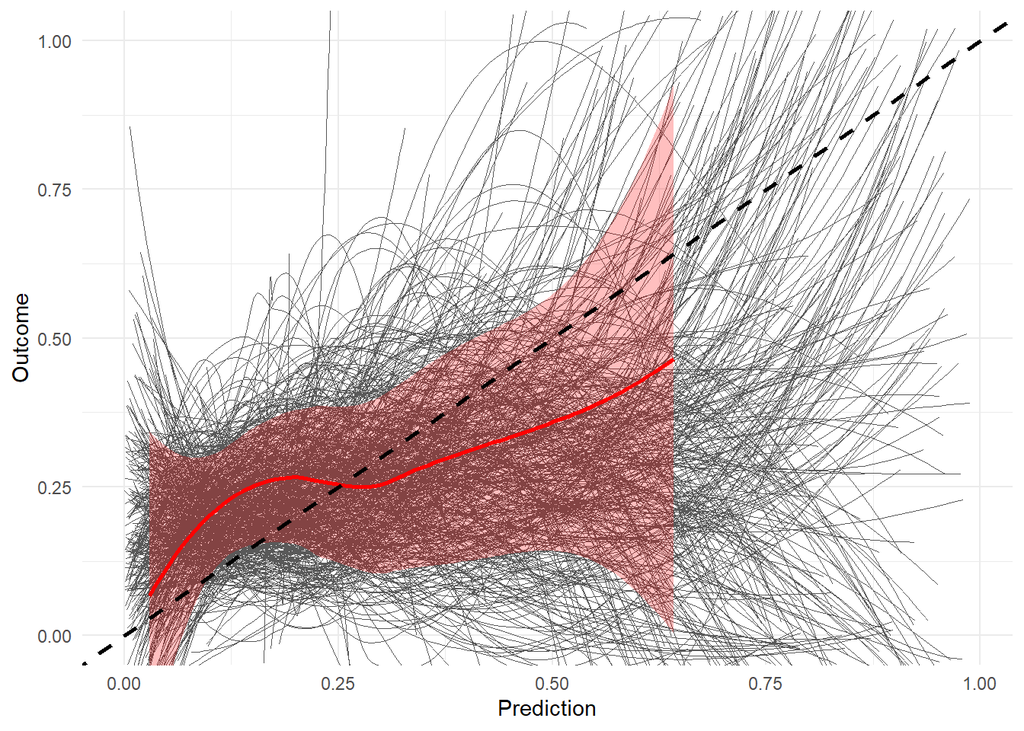

```r
enet_model$plot
```

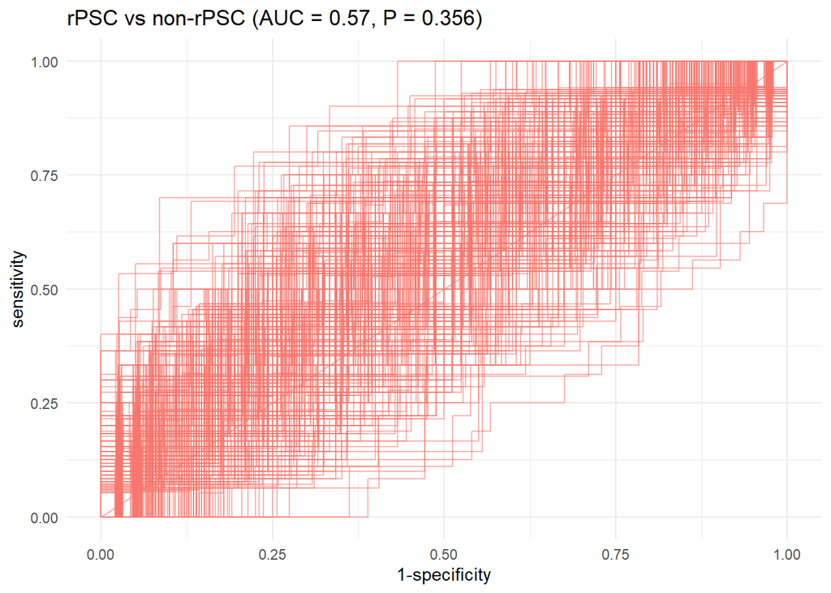

```r
roc_c
```

##### 2.5.1.1.2 rPSC vs non-rPSC - subset

```r
group <- c("rPSC","non-rPSC")
comparison_name <- paste0(group[1], " vs ",group[2]," subset")
```

```r
taxa_to_test <- read.xlsx("../../../results/merged_sites/main_analysis/Q1/univariate_analysis/significant_taxa_terminal_ileum.xlsx", sheet=" genus healthy vs pre_ltx")

model_name <- paste(comparison_name,level,segment)

# prepare the data
filt_ileum_uni_data <- binomial_prep_psc_effect(ileum_genus_tab,
                                                ileum_genus_taxa_tab,
                                                ileum_metadata,
                                                taxa_to_test,
                                                usage="ml_clr")
```

```
Removing 55 ASV(s)
```

```
Removing 2 ASV(s)
```

```r
# fit the model
enet_model <- glmnet_binomial(filt_ileum_uni_data,
                              sample_method = "atypboot",
                              outcome="Group",
                              N=500,
                              reuse=TRUE,
                              file=model_name,
                              Q="Q2")

# ROC
roc_c <- roc_curve(enet_model, group)

# save the results
models_summ[[model_name]] <- enet_model$model_summary
models_cm[[model_name]] <- enet_model$conf_matrices$original
roc_cs[[model_name]] <- enet_model$kfold_rocobjs
betas[[model_name]] <- as.matrix(enet_model$betas)

# see the results
enet_model$model_summary %>% t()
```

```
                                     [,1]
alpha                           0.2000000
lambda                          0.5017248
auc                             0.5160173
auc_czech                       0.5224359
auc_no                          0.5000000
auc_optimism_corrected          0.5599297
auc_optimism_corrected_CIL      0.3863553
auc_optimism_corrected_CIU      0.7232201
accuracy                        0.7608696
accuracy_czech                        NaN
accuracy_no                     0.7500000
accuracy_optimism_corrected     0.7539422
accuracy_optimism_corrected_CIL 0.6525954
accuracy_optimism_corrected_CIU 0.8442308
```

```r
enet_model$conf_matrices
```

```
$original
    0
0 105 0
1  33 0

$czech
   0
0 78 0
1 24 0

$no
   0
0 27 0
1  9 0
```

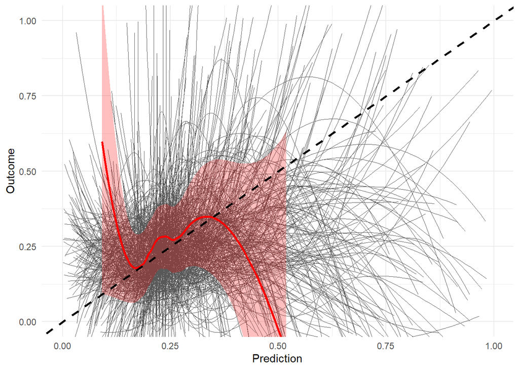

```r
enet_model$plot
```

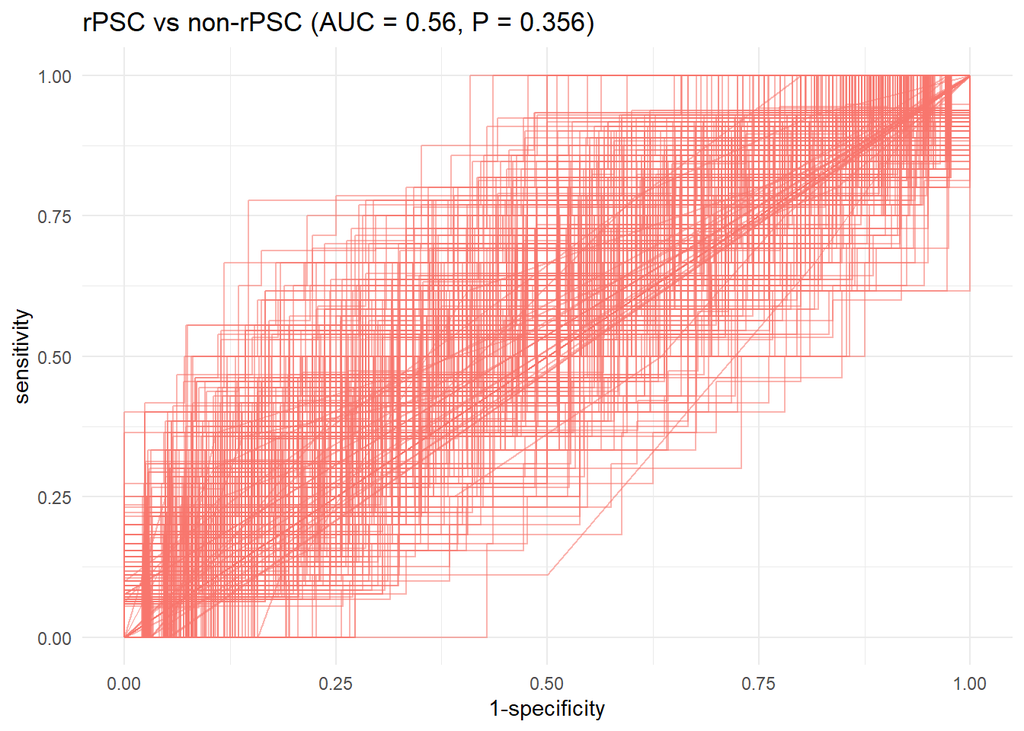

```r
roc_c
```

#### 2.5.1.2 Saving results

```r
models_summ_df_ileum <- do.call(rbind,
  models_summ[grep(segment,names(models_summ),value = TRUE)])

write.csv(models_summ_df_ileum,file.path(path,paste0("elastic_net_",segment,".csv")))
```

## 2.6 Results overview

#### 2.6.0.1 Alpha diversity

**Models**

```r
knitr::kable(pc_observed[[segment]],
             digits = 3,
             caption = "Results of linear model testing ASV Richness")
```

Results of linear model testing ASV Richness

|  | Estimate | Std..Error | t.value | Pr…t.. | p.adj | sig |
| --- | --- | --- | --- | --- | --- | --- |
| non-rPSC vs GrouprPSC | -12.199 | 11.972 | -1.019 | 0.310 | 0.349 |  |
| non-rPSC , rPSC - CZ vs NO | -21.486 | 11.452 | -1.876 | 0.063 | 0.141 |  |
| non-rPSC vs GrouprPSC:CountryNO | 9.347 | 23.088 | 0.405 | 0.686 | 0.686 |  |
| healthy vs GrouprPSC | -37.741 | 12.284 | -3.072 | 0.003 | 0.025 | * |
| healthy , rPSC - CZ vs NO | 11.203 | 10.973 | 1.021 | 0.310 | 0.349 |  |
| healthy vs GrouprPSC:CountryNO | -23.342 | 21.355 | -1.093 | 0.277 | 0.349 |  |
| healthy vs Groupnon-rPSC | -25.542 | 9.322 | -2.740 | 0.007 | 0.031 | * |
| healthy , non-rPSC - CZ vs NO | 11.203 | 10.933 | 1.025 | 0.307 | 0.349 |  |
| healthy vs Groupnon-rPSC:CountryNO | -32.689 | 15.108 | -2.164 | 0.032 | 0.096 |  |

```r
knitr::kable(pc_shannon[[segment]],
             digits = 3,
             caption = "Results of linear model testing Shannon index")
```

Results of linear model testing Shannon index

|  | Estimate | Std..Error | t.value | Pr…t.. | p.adj | sig |
| --- | --- | --- | --- | --- | --- | --- |
| non-rPSC vs GrouprPSC | -0.102 | 0.146 | -0.696 | 0.487 | 0.731 |  |
| non-rPSC , rPSC - CZ vs NO | -0.349 | 0.140 | -2.500 | 0.014 | 0.123 |  |
| non-rPSC vs GrouprPSC:CountryNO | -0.006 | 0.281 | -0.021 | 0.983 | 0.983 |  |
| healthy vs GrouprPSC | -0.210 | 0.140 | -1.501 | 0.137 | 0.321 |  |
| healthy , rPSC - CZ vs NO | 0.005 | 0.125 | 0.043 | 0.966 | 0.983 |  |
| healthy vs GrouprPSC:CountryNO | -0.360 | 0.244 | -1.478 | 0.142 | 0.321 |  |
| healthy vs Groupnon-rPSC | -0.109 | 0.115 | -0.948 | 0.344 | 0.620 |  |
| healthy , non-rPSC - CZ vs NO | 0.005 | 0.135 | 0.040 | 0.968 | 0.983 |  |
| healthy vs Groupnon-rPSC:CountryNO | -0.354 | 0.186 | -1.905 | 0.058 | 0.263 |  |

```r
knitr::kable(pc_simpson[[segment]],
             digits = 3,
             caption = "Results of linear model testing Simpson index")
```

Results of linear model testing Simpson index

|  | Estimate | Std..Error | t.value | Pr…t.. | p.adj | sig |
| --- | --- | --- | --- | --- | --- | --- |
| non-rPSC vs GrouprPSC | 0.000 | 0.023 | 0.019 | 0.985 | 0.985 |  |
| non-rPSC , rPSC - CZ vs NO | -0.034 | 0.022 | -1.573 | 0.118 | 0.531 |  |
| non-rPSC vs GrouprPSC:CountryNO | -0.029 | 0.043 | -0.661 | 0.510 | 0.767 |  |
| healthy vs GrouprPSC | -0.009 | 0.018 | -0.500 | 0.618 | 0.767 |  |
| healthy , rPSC - CZ vs NO | -0.008 | 0.016 | -0.501 | 0.617 | 0.767 |  |
| healthy vs GrouprPSC:CountryNO | -0.055 | 0.031 | -1.779 | 0.078 | 0.531 |  |
| healthy vs Groupnon-rPSC | -0.009 | 0.016 | -0.564 | 0.574 | 0.767 |  |
| healthy , non-rPSC - CZ vs NO | -0.008 | 0.019 | -0.410 | 0.682 | 0.767 |  |
| healthy vs Groupnon-rPSC:CountryNO | -0.026 | 0.027 | -0.975 | 0.331 | 0.767 |  |

```r
knitr::kable(pc_pielou[[segment]],
             digits = 3,
             caption = "Results of linear model testing Pielou index")
```

Results of linear model testing Pielou index

|  | Estimate | Std..Error | t.value | Pr…t.. | p.adj | sig |
| --- | --- | --- | --- | --- | --- | --- |
| non-rPSC vs GrouprPSC | -0.004 | 0.022 | -0.184 | 0.854 | 0.946 |  |
| non-rPSC , rPSC - CZ vs NO | -0.047 | 0.021 | -2.260 | 0.025 | 0.229 |  |
| non-rPSC vs GrouprPSC:CountryNO | -0.005 | 0.042 | -0.108 | 0.914 | 0.946 |  |
| healthy vs GrouprPSC | -0.001 | 0.021 | -0.067 | 0.946 | 0.946 |  |
| healthy , rPSC - CZ vs NO | -0.009 | 0.018 | -0.463 | 0.645 | 0.946 |  |
| healthy vs GrouprPSC:CountryNO | -0.043 | 0.036 | -1.195 | 0.235 | 0.705 |  |
| healthy vs Groupnon-rPSC | 0.003 | 0.018 | 0.146 | 0.884 | 0.946 |  |
| healthy , non-rPSC - CZ vs NO | -0.009 | 0.021 | -0.409 | 0.683 | 0.946 |  |
| healthy vs Groupnon-rPSC:CountryNO | -0.038 | 0.029 | -1.329 | 0.185 | 0.705 |  |

**Plots**

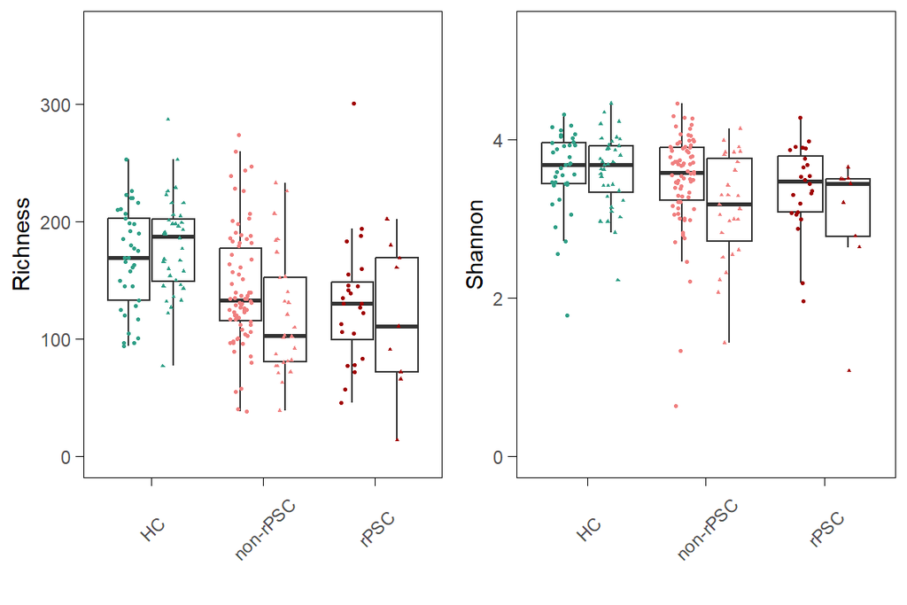

```r
alpha_div_plots[[paste(segment,"Country")]]
```

#### 2.6.0.2 Beta diversity

**Main results**

```r
knitr::kable(pairwise_aitchison_raw[[paste("genus", segment)]],
             digits = 3,
             caption = "Results of PERMANOVA - robust aitchison distance")
```

Results of PERMANOVA - robust aitchison distance

| pairs | Df | SumsOfSqs | F.Model | R2 | p.value | p.adjusted | sig |
| --- | --- | --- | --- | --- | --- | --- | --- |
| rPSC vs non-rPSC | 1 | 215.579 | 1.208 | 0.009 | 0.107 | 0.107 |  |
| rPSC vs healthy | 1 | 561.696 | 3.345 | 0.030 | 0.001 | 0.002 | ** |
| non-rPSC vs healthy | 1 | 760.242 | 4.431 | 0.024 | 0.001 | 0.002 | ** |
| rPSC vs non-rPSC , Country | 1 | 601.929 | 3.372 | 0.024 | 0.001 | 0.001 | *** |
| rPSC vs healthy , Country | 1 | 496.841 | 2.959 | 0.027 | 0.001 | 0.001 | *** |
| non-rPSC vs healthy , Country | 1 | 624.474 | 3.640 | 0.020 | 0.001 | 0.001 | *** |
| rPSC vs non-rPSC : Country | 1 | 156.176 | 0.874 | 0.006 | 0.788 | 0.788 |  |
| rPSC vs healthy : Country | 1 | 164.743 | 0.981 | 0.009 | 0.464 | 0.696 |  |
| non-rPSC vs healthy : Country | 1 | 209.954 | 1.225 | 0.007 | 0.089 | 0.267 |  |

**PCA**

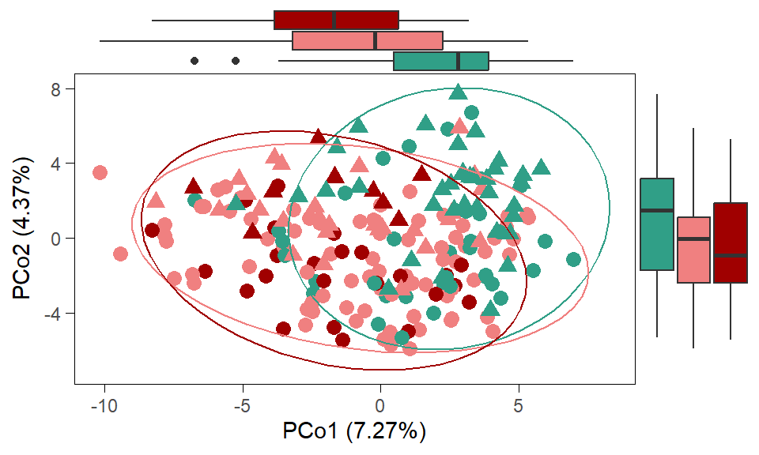

```r
pca_plots_list[[paste(segment,"genus custom")]]
```

#### 2.6.0.3 Univariate analysis

**Number of significant taxa**

```r
knitr::kable(cbind(as.data.frame(lapply(list_intersections,nrow)),
      as.data.frame(lapply(rpsc_effect,nrow))) %>% t() %>%
  `colnames<-`("Count") %>%
  `rownames<-`(c(names(list_intersections),"PSC effect Genus")),caption="Number of significant taxa")
```

Number of significant taxa

|  | Count |
| --- | --- |
| terminal_ileum genus non-rPSC vs rPSC | 0 |
| terminal_ileum genus healthy vs rPSC | 34 |
| terminal_ileum genus healthy vs non-rPSC | 25 |
| PSC effect Genus | 16 |

#### 2.6.0.4 Machine learning

**Main models**

```r
knitr::kable(models_summ_df_ileum %>% dplyr::select(
"alpha","lambda",
"auc_optimism_corrected",
"auc_optimism_corrected_CIL",
"auc_optimism_corrected_CIU"),
             digits=2,caption="Elastic net results")
```

Elastic net results

|  | alpha | lambda | auc_optimism_corrected | auc_optimism_corrected_CIL | auc_optimism_corrected_CIU |
| --- | --- | --- | --- | --- | --- |
| rPSC vs non-rPSC genus terminal_ileum | 0.4 | 0.31 | 0.57 | 0.39 | 0.73 |
| rPSC vs non-rPSC subset genus terminal_ileum | 0.2 | 0.50 | 0.56 | 0.39 | 0.72 |

**ROC - Genus level**

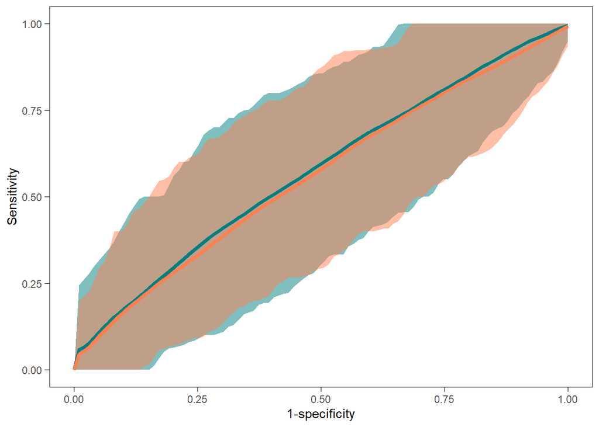

```r
p <- roc_curve_all_custom(roc_cs[c(1:2)],Q="Q2",
                     model_name="enet_model",legend = FALSE)

p
```

# 3 Data Analysis - Colon

```r
segment="colon"
```

## 3.1 Filtering

Rules: - sequencing depth > 10000

- nearZeroVar() with default settings

**Rarefaction Curve**

```r
path="../../../intermediate_files/rarecurves"
seq_depth_threshold <- 10000
```

```r
ps <- construct_phyloseq(colon_asv_tab,colon_taxa_tab,colon_metadata)
rareres <- get_rarecurve(obj=ps, chunks=500)
save(rareres,file = file.path(path,"rarefaction_colon.Rdata"))
```

```r
load(file.path(path,"rarefaction_colon.Rdata"))
seq_depth_threshold <- 10000
prare <- ggrarecurve(obj=rareres,
                      factorNames="Country",
                      indexNames=c("Observe")) +
        theme_bw()+
        theme(axis.text=element_text(size=8),
              panel.grid=element_blank(),
              strip.background = element_rect(colour=NA,fill="grey"),
              strip.text.x = element_text(face="bold")) +
        geom_vline(xintercept = seq_depth_threshold,
                   linetype="dashed", color = "red") +
        xlim(0, 20000)
```

```
The color has been set automatically, you can reset it manually by adding scale_color_manual(values=yourcolors)
```

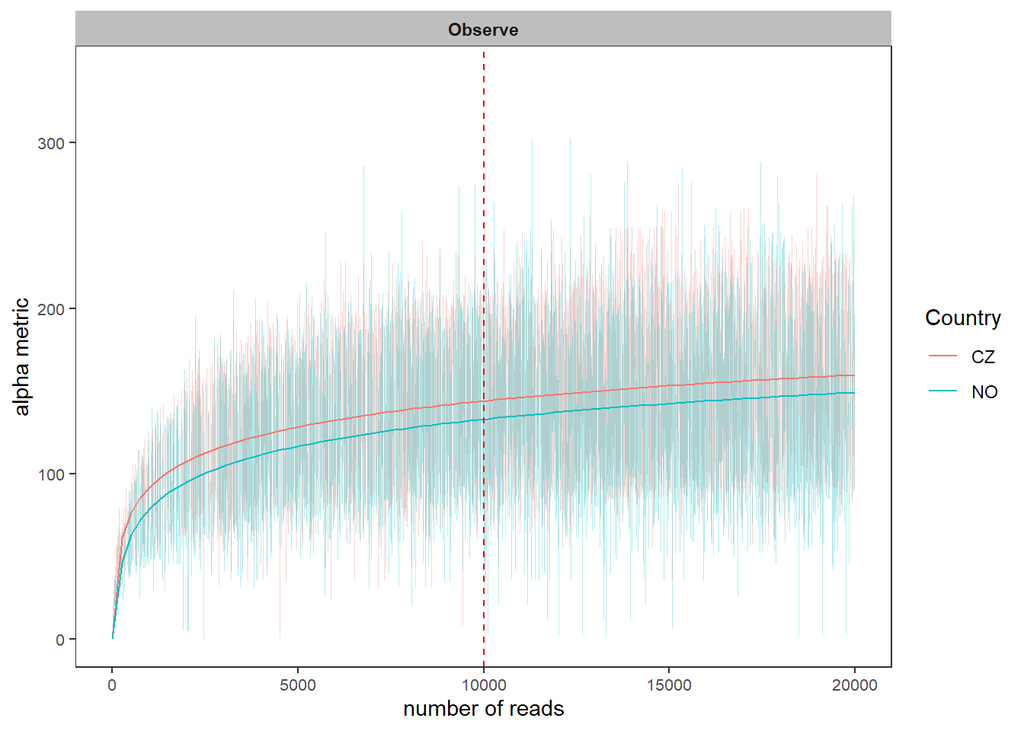

```r
prare
```

Library size

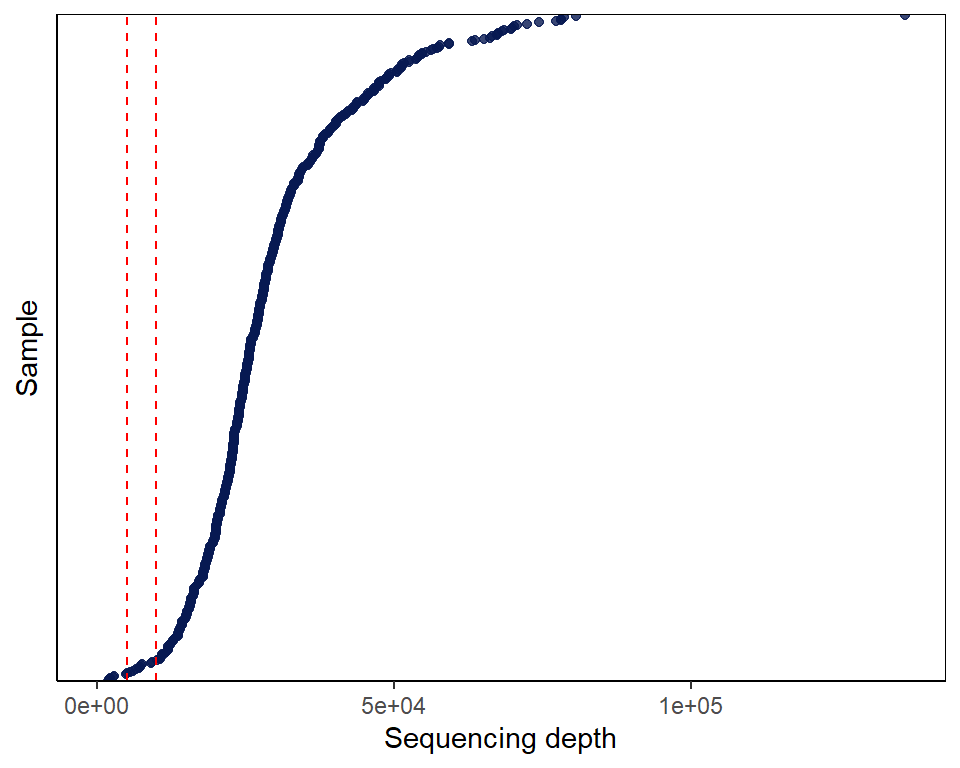

```r
read_counts(colon_asv_tab, line = c(5000,10000))
```

### 3.1.1 Sequencing depth

```r
data_filt <- seq_depth_filtering(colon_asv_tab,
                                 colon_taxa_tab,
                                 colon_metadata,
                                 seq_depth_threshold = 10000)
```

```
Removing 50 ASV(s)
```

```r
filt_colon_asv_tab <- data_filt[[1]]; alpha_colon_asv_tab <- filt_colon_asv_tab
filt_colon_taxa_tab <- data_filt[[2]]; alpha_colon_taxa_tab <- filt_colon_taxa_tab
filt_colon_metadata <- data_filt[[3]]; alpha_colon_metadata <- filt_colon_metadata

seq_step <- dim(filt_colon_asv_tab)[1]
```

Library size

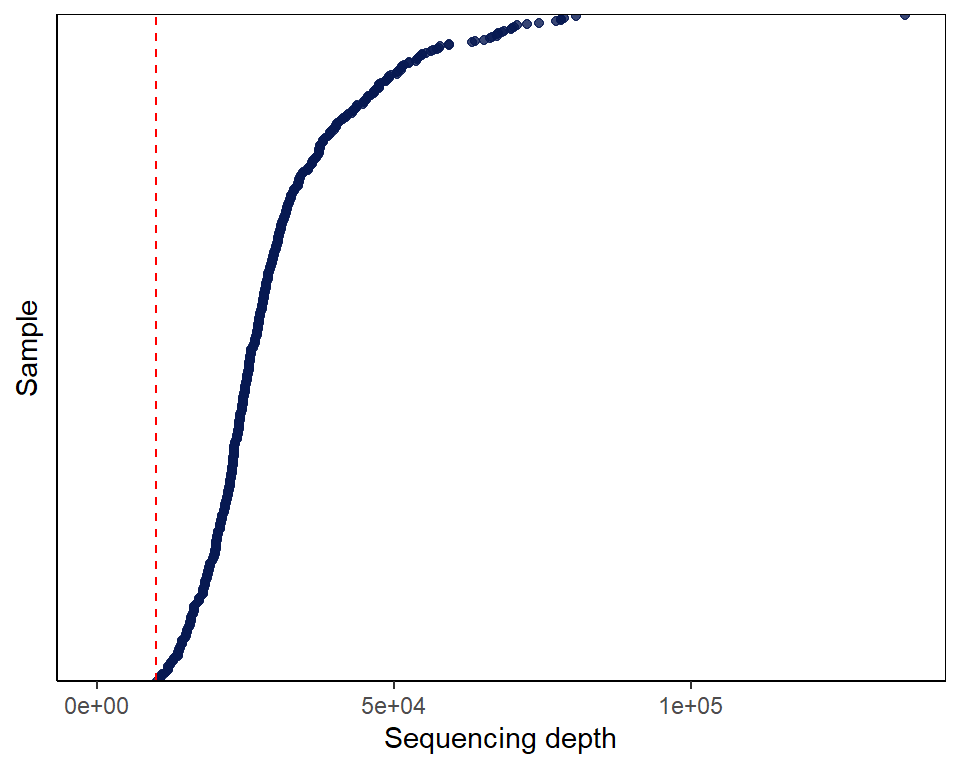

```r
read_counts(filt_colon_asv_tab,line = c(10000))
```

### 3.1.2 NearZeroVar

```r
data_filt <- nearzerovar_filtering(filt_colon_asv_tab,
                                   filt_colon_taxa_tab,
                                   filt_colon_metadata)

filt_colon_asv_tab <- data_filt[[1]]
filt_colon_taxa_tab <- data_filt[[2]]
nearzero_step <- dim(filt_colon_asv_tab)[1]
```

Library size

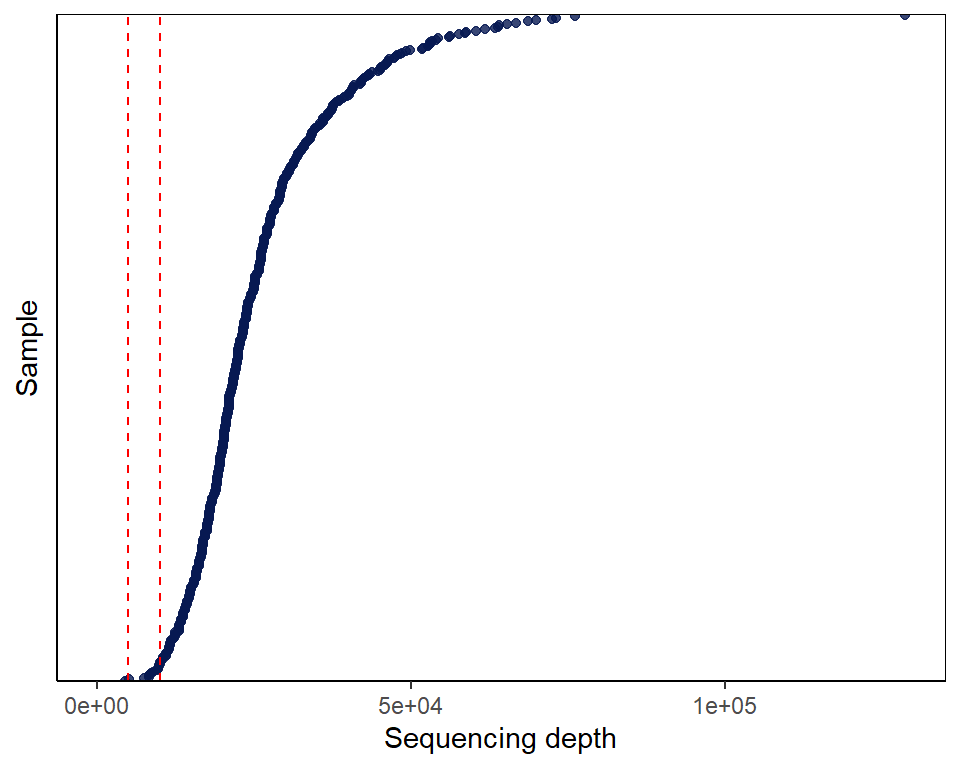

```r
read_counts(filt_colon_asv_tab,line = c(5000,10000))
```

Check zero depth

```r
data_filt <- check_zero_depth(filt_colon_asv_tab,
                              filt_colon_taxa_tab,
                              filt_colon_metadata)

filt_colon_asv_tab <- data_filt[[1]];
filt_colon_taxa_tab <- data_filt[[2]];
filt_colon_metadata <- data_filt[[3]];
```

Library size

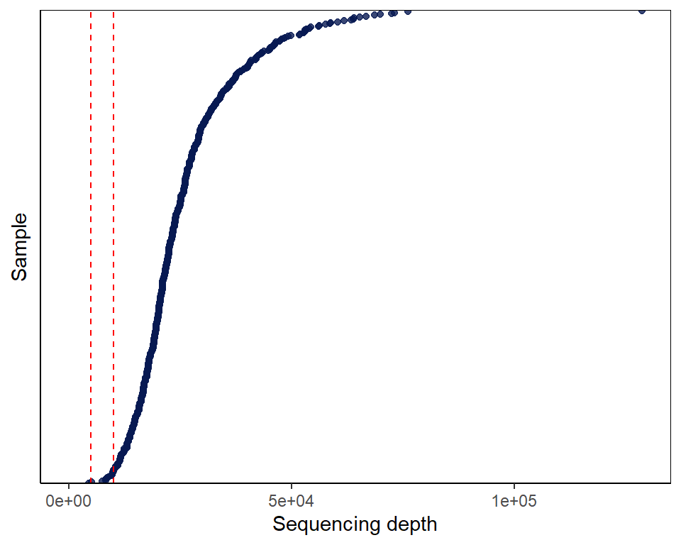

```r
read_counts(filt_colon_asv_tab,line = c(5000,10000))
```

### 3.1.3 Final Counts

```r
final_counts_filtering(colon_asv_tab,
                       filt_colon_asv_tab,
                       filt_colon_metadata,
                       seq_step, 0, nearzero_step)
```

```
                                               V1
Raw data: ASVs                               5840
Raw data: Samples                             527
Sequencing depth filt: ASVs                  5790
Prevalence filt: ASVs                           0
NearZeroVar filt: ASVs                        444
Filt data: ASVs                               444
Filt data: Samples                            511
Filt data: Patients                           250
Filt data: Patients.1                           0
Filtered samples                               16
Matrices                    Cecum;Rectum;CD;CA;SI
healthy                                       161
non-rPSC                                      263
rPSC                                           87
pre_ltx                                         0
post_ltx                                        0
ETOH                                            0
```

## 3.2 Alpha diversity

```r
path = "../../../results/merged_sites/main_analysis/Q2/alpha_diversity"
```

**Calculation**

```r
# Construct MPSE object
alpha_colon_metadata$Sample <- alpha_colon_metadata$SampleID
colon_mpse <- as.MPSE(construct_phyloseq(alpha_colon_asv_tab,
                                         alpha_colon_taxa_tab,
                                         alpha_colon_metadata))

colon_mpse %<>% mp_rrarefy(raresize = 10000,seed = 123)

# Calculate alpha diversity - rarefied counts
colon_mpse %<>% mp_cal_alpha(.abundance=RareAbundance, force=TRUE)
```

```r
alpha_data <- data.frame(SampleID=colon_mpse$Sample.x,
                         Observe=colon_mpse$Observe,
                         Shannon=colon_mpse$Shannon,
                         Simpson=colon_mpse$Simpson,
                         Pielou=colon_mpse$Pielou,
                         Group=colon_mpse$Group,
                         Country=colon_mpse$Country,
                         Patient=colon_mpse$Patient)

write.csv(alpha_data,file.path(path,paste0("alpha_indices_",segment,".csv")),
          row.names = FALSE)
```

### 3.2.1 Plots

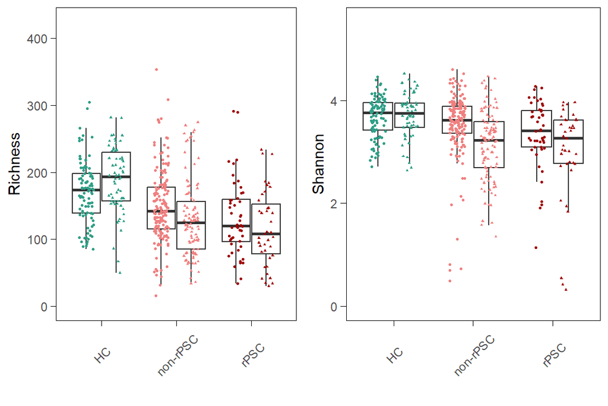

```r
p_boxplot_alpha <- alpha_diversity_countries(alpha_data)
# save the results
alpha_div_plots[[paste(segment,"Country")]] <- p_boxplot_alpha

# see the results
p_boxplot_alpha
```

### 3.2.2 Linear Models

```r
path = "../../../results/merged_sites/main_analysis/Q2/alpha_diversity"
alpha_data <- read.csv(file.path(path,paste0("alpha_indices_",segment,".csv")))
```

**Richness**

```r
results_model <- pairwise.lmer(
  formula = "Observe ~ Group * Country + (1|Patient)",
  factors=alpha_data$Group,
  data=alpha_data)

# check interaction
if (!is.data.frame(results_model)){
  results_model_observe <- results_model[[1]]
  results_model_observe_detailed <- results_model[[2]]
} else {
  results_model_observe <- results_model
  results_model_observe_detailed <- NA
}

# save the results
pc_observed[[segment]] <- results_model_observe
```

```r
# see the results
knitr::kable(results_model_observe,digits = 3,
caption = "Raw results of linear model of richness estimation.")
```

Raw results of linear model of richness estimation.

|  | Estimate | Std..Error | df | t.value | Pr…t.. | p.adj | sig |
| --- | --- | --- | --- | --- | --- | --- | --- |
| non-rPSC vs GrouprPSC | -17.252 | 12.469 | 156.883 | -1.384 | 0.168 | 0.192 |  |
| non-rPSC vs rPSC - CZ vs NO | -17.941 | 10.644 | 153.303 | -1.686 | 0.094 | 0.192 |  |
| non-rPSC vs GrouprPSC:CountryNO | 3.483 | 21.371 | 152.108 | 0.163 | 0.871 | 0.871 |  |
| healthy vs GrouprPSC | -40.307 | 11.924 | 125.516 | -3.380 | 0.001 | 0.009 | ** |
| healthy vs rPSC - CZ vs NO | 14.783 | 10.544 | 126.613 | 1.402 | 0.163 | 0.192 |  |
| healthy vs GrouprPSC:CountryNO | -29.232 | 19.769 | 123.028 | -1.479 | 0.142 | 0.192 |  |
| healthy vs Groupnon-rPSC | -22.976 | 8.905 | 211.354 | -2.580 | 0.011 | 0.047 | * |
| healthy vs non-rPSC - CZ vs NO | 14.961 | 10.892 | 212.956 | 1.374 | 0.171 | 0.192 |  |
| healthy vs Groupnon-rPSC:CountryNO | -32.911 | 14.701 | 208.353 | -2.239 | 0.026 | 0.079 |  |

```r
knitr::kable(results_model_observe_detailed,digits = 3,
caption = "Raw results of independent country analysis")
```

Raw results of independent country analysis

|  | Estimate | Std. Error | df | t value | Pr(>\|t\|) | p.adjusted |
| --- | --- | --- | --- | --- | --- | --- |
| healthy_CZ | 171.439 | 6.808 | 137.314 | 25.182 | 0.000 | NA |
| Groupnon-rPSC | -22.949 | 8.722 | 135.888 | -2.631 | 0.009 | 0.019 |

|  | Estimate | Std. Error | df | t value | Pr(>\|t\|) | p.adjusted |
| --- | --- | --- | --- | --- | --- | --- |
| healthy_NO | 186.365 | 8.682 | 75.472 | 21.467 | 0 | NA |
| Groupnon-rPSC | -55.850 | 12.120 | 73.619 | -4.608 | 0 | 0 |

|  | Estimate | Std. Error | df | t value | Pr(>\|t\|) | p.adjusted |
| --- | --- | --- | --- | --- | --- | --- |
| healthy_CZ | 171.468 | 6.275 | 89.628 | 27.325 | 0.000 | NA |
| CountryNO | 14.904 | 9.836 | 89.468 | 1.515 | 0.133 | 0.133 |

|  | Estimate | Std. Error | df | t value | Pr(>\|t\|) | p.adjusted |
| --- | --- | --- | --- | --- | --- | --- |
| non-rPSC_CZ | 148.477 | 5.932 | 120.279 | 25.028 | 0.000 | NA |
| CountryNO | -17.950 | 10.519 | 117.183 | -1.706 | 0.091 | 0.121 |

**Shannon**

```r
results_model <- pairwise.lmer(
  formula = "Shannon ~ Group * Country + (1|Patient)",
  factors=alpha_data$Group,
  data=alpha_data)

# check interaction
if (!is.data.frame(results_model)){
  results_model_shannon <- results_model[[1]]
  results_model_shannon_detailed <- results_model[[2]]
} else {
  results_model_shannon <- results_model
  results_model_shannon_detailed <- NA
}

# save the results
pc_shannon[[segment]] <- as.data.frame(results_model_shannon)
```

```r
# see the results
knitr::kable(results_model_shannon,digits = 3,
caption = "Raw results of linear model of Shannon estimation.")
```

Raw results of linear model of Shannon estimation.

|  | Estimate | Std..Error | df | t.value | Pr…t.. | p.adj | sig |
| --- | --- | --- | --- | --- | --- | --- | --- |
| non-rPSC vs GrouprPSC | -0.146 | 0.161 | 154.485 | -0.907 | 0.366 | 0.549 |  |
| non-rPSC vs rPSC - CZ vs NO | -0.355 | 0.138 | 151.788 | -2.581 | 0.011 | 0.051 |  |
| non-rPSC vs GrouprPSC:CountryNO | 0.008 | 0.277 | 150.856 | 0.030 | 0.976 | 0.976 |  |
| healthy vs GrouprPSC | -0.330 | 0.128 | 126.201 | -2.572 | 0.011 | 0.051 |  |
| healthy vs rPSC - CZ vs NO | 0.017 | 0.113 | 127.217 | 0.146 | 0.884 | 0.976 |  |
| healthy vs GrouprPSC:CountryNO | -0.364 | 0.213 | 123.907 | -1.709 | 0.090 | 0.162 |  |
| healthy vs Groupnon-rPSC | -0.182 | 0.101 | 207.051 | -1.795 | 0.074 | 0.162 |  |
| healthy vs non-rPSC - CZ vs NO | 0.018 | 0.124 | 208.617 | 0.145 | 0.884 | 0.976 |  |
| healthy vs Groupnon-rPSC:CountryNO | -0.375 | 0.168 | 204.129 | -2.240 | 0.026 | 0.078 |  |

```r
knitr::kable(results_model_shannon_detailed,digits = 3,
caption = "Raw results of independent country analysis")
```

Raw results of independent country analysis

|  | Estimate | Std. Error | df | t value | Pr(>\|t\|) | p.adjusted |
| --- | --- | --- | --- | --- | --- | --- |
| healthy_CZ | 3.683 | 0.065 | 77.802 | 56.300 | 0.000 | NA |
| GrouprPSC | -0.330 | 0.116 | 76.679 | -2.846 | 0.006 | 0.011 |

|  | Estimate | Std. Error | df | t value | Pr(>\|t\|) | p.adjusted |
| --- | --- | --- | --- | --- | --- | --- |
| healthy_NO | 3.700 | 0.099 | 48.693 | 37.40 | 0.000 | NA |
| GrouprPSC | -0.693 | 0.193 | 47.827 | -3.59 | 0.001 | 0.003 |

|  | Estimate | Std. Error | df | t value | Pr(>\|t\|) | p.adjusted |
| --- | --- | --- | --- | --- | --- | --- |
| healthy_CZ | 3.683 | 0.054 | 89.061 | 68.505 | 0.000 | NA |
| CountryNO | 0.019 | 0.084 | 88.828 | 0.231 | 0.818 | 0.818 |

|  | Estimate | Std. Error | df | t value | Pr(>\|t\|) | p.adjusted |
| --- | --- | --- | --- | --- | --- | --- |
| rPSC_CZ | 3.354 | 0.153 | 36.206 | 21.939 | 0.000 | NA |
| CountryNO | -0.347 | 0.261 | 35.912 | -1.332 | 0.191 | 0.255 |

|  | Estimate | Std. Error | df | t value | Pr(>\|t\|) | p.adjusted |
| --- | --- | --- | --- | --- | --- | --- |
| healthy_CZ | 3.684 | 0.081 | 133.503 | 45.582 | 0.000 | NA |
| Groupnon-rPSC | -0.184 | 0.104 | 132.547 | -1.772 | 0.079 | 0.105 |

|  | Estimate | Std. Error | df | t value | Pr(>\|t\|) | p.adjusted |
| --- | --- | --- | --- | --- | --- | --- |
| healthy_NO | 3.702 | 0.093 | 77.069 | 39.853 | 0 | NA |
| Groupnon-rPSC | -0.559 | 0.129 | 74.201 | -4.324 | 0 | 0 |

|  | Estimate | Std. Error | df | t value | Pr(>\|t\|) | p.adjusted |
| --- | --- | --- | --- | --- | --- | --- |
| healthy_CZ | 3.683 | 0.054 | 89.061 | 68.505 | 0.000 | NA |
| CountryNO | 0.019 | 0.084 | 88.828 | 0.231 | 0.818 | 0.818 |

|  | Estimate | Std. Error | df | t value | Pr(>\|t\|) | p.adjusted |
| --- | --- | --- | --- | --- | --- | --- |
| non-rPSC_CZ | 3.501 | 0.075 | 117.089 | 46.588 | 0.000 | NA |
| CountryNO | -0.357 | 0.133 | 114.586 | -2.673 | 0.009 | 0.017 |

**Simpson**

```r
results_model <- pairwise.lmer(
  formula = "Simpson ~ Group * Country + (1|Patient)",
  factors=alpha_data$Group,
  data=alpha_data)

# check interaction
if (!is.data.frame(results_model)){
  results_model_simpson <- results_model[[1]]
  results_model_simpson_detailed <- results_model[[2]]
} else {
  results_model_simpson <- results_model
  results_model_simpson_detailed <- NA
}

# save the results
pc_simpson[[segment]] <- as.data.frame(results_model_simpson)
```

```r
# see the results
knitr::kable(results_model_simpson,digits = 3,
caption = "Raw results of linear model of Simpson estimation.")
```

Raw results of linear model of Simpson estimation.

|  | Estimate | Std..Error | df | t.value | Pr…t.. | p.adj | sig |
| --- | --- | --- | --- | --- | --- | --- | --- |
| non-rPSC vs GrouprPSC | -0.005 | 0.029 | 153.608 | -0.169 | 0.866 | 0.866 |  |
| non-rPSC vs rPSC - CZ vs NO | -0.032 | 0.024 | 151.251 | -1.296 | 0.197 | 0.443 |  |
| non-rPSC vs GrouprPSC:CountryNO | -0.027 | 0.049 | 150.427 | -0.554 | 0.581 | 0.806 |  |
| healthy vs GrouprPSC | -0.031 | 0.020 | 127.660 | -1.523 | 0.130 | 0.391 |  |
| healthy vs rPSC - CZ vs NO | -0.007 | 0.018 | 128.411 | -0.402 | 0.688 | 0.806 |  |
| healthy vs GrouprPSC:CountryNO | -0.052 | 0.034 | 125.982 | -1.540 | 0.126 | 0.391 |  |
| healthy vs Groupnon-rPSC | -0.026 | 0.016 | 201.924 | -1.600 | 0.111 | 0.391 |  |
| healthy vs non-rPSC - CZ vs NO | -0.007 | 0.020 | 203.469 | -0.363 | 0.717 | 0.806 |  |
| healthy vs Groupnon-rPSC:CountryNO | -0.025 | 0.026 | 199.046 | -0.952 | 0.342 | 0.616 |  |

```r
knitr::kable(results_model_simpson_detailed,digits = 3,
caption = "Raw results of independent country analysis")
```

Table: Raw results of independent country analysis

**Pielou**

```r
results_model <- pairwise.lmer(
  formula = "Pielou ~ Group * Country + (1|Patient)",
  factors=alpha_data$Group,
  data=alpha_data)

# check interaction
if (!is.data.frame(results_model)){
  results_model_pielou <- results_model[[1]]
  results_model_pielou_detailed <- results_model[[2]]
} else {
  results_model_pielou <- results_model
  results_model_pielou_detailed <- NA
}

# save the results
pc_pielou[[segment]] <- as.data.frame(results_model_pielou)
```

```r
# see the results
knitr::kable(results_model_pielou,digits = 3,
caption = "Raw results of linear model of Pielou estimation.")
```

Raw results of linear model of Pielou estimation.

|  | Estimate | Std..Error | df | t.value | Pr…t.. | p.adj | sig |
| --- | --- | --- | --- | --- | --- | --- | --- |
| non-rPSC vs GrouprPSC | -0.007 | 0.026 | 153.863 | -0.292 | 0.771 | 0.843 |  |
| non-rPSC vs rPSC - CZ vs NO | -0.052 | 0.022 | 150.735 | -2.372 | 0.019 | 0.171 |  |
| non-rPSC vs GrouprPSC:CountryNO | -0.009 | 0.044 | 149.674 | -0.198 | 0.843 | 0.843 |  |
| healthy vs GrouprPSC | -0.023 | 0.020 | 127.665 | -1.183 | 0.239 | 0.538 |  |
| healthy vs rPSC - CZ vs NO | -0.008 | 0.017 | 129.013 | -0.457 | 0.648 | 0.843 |  |
| healthy vs GrouprPSC:CountryNO | -0.052 | 0.033 | 124.565 | -1.605 | 0.111 | 0.333 |  |
| healthy vs Groupnon-rPSC | -0.015 | 0.015 | 204.651 | -1.006 | 0.316 | 0.568 |  |
| healthy vs non-rPSC - CZ vs NO | -0.008 | 0.019 | 206.473 | -0.416 | 0.678 | 0.843 |  |
| healthy vs Groupnon-rPSC:CountryNO | -0.044 | 0.025 | 201.171 | -1.745 | 0.083 | 0.333 |  |

```r
knitr::kable(results_model_pielou_detailed,digits = 3,
caption = "Raw results of independent country analysis")
```

Raw results of independent country analysis

|  | Estimate | Std. Error | df | t value | Pr(>\|t\|) | p.adjusted |
| --- | --- | --- | --- | --- | --- | --- |
| healthy_CZ | 0.720 | 0.013 | 132.894 | 56.00 | 0.000 | NA |
| Groupnon-rPSC | -0.016 | 0.016 | 132.038 | -0.97 | 0.334 | 0.445 |

|  | Estimate | Std. Error | df | t value | Pr(>\|t\|) | p.adjusted |
| --- | --- | --- | --- | --- | --- | --- |
| healthy_NO | 0.713 | 0.013 | 79.537 | 55.174 | 0.000 | NA |
| Groupnon-rPSC | -0.060 | 0.018 | 74.995 | -3.379 | 0.001 | 0.005 |

|  | Estimate | Std. Error | df | t value | Pr(>\|t\|) | p.adjusted |
| --- | --- | --- | --- | --- | --- | --- |
| healthy_CZ | 0.720 | 0.007 | 89.185 | 99.650 | 0.000 | NA |
| CountryNO | -0.008 | 0.011 | 88.856 | -0.667 | 0.506 | 0.506 |

|  | Estimate | Std. Error | df | t value | Pr(>\|t\|) | p.adjusted |
| --- | --- | --- | --- | --- | --- | --- |
| non-rPSC_CZ | 0.705 | 0.012 | 115.555 | 60.129 | 0.000 | NA |
| CountryNO | -0.052 | 0.021 | 112.732 | -2.499 | 0.014 | 0.028 |

### 3.2.3 Saving results

```r
alpha_list <- list(
  Richness=pc_observed[[segment]] %>% rownames_to_column("Comparison"),
  Shannon=pc_shannon[[segment]] %>% rownames_to_column("Comparison"),
  Simpson=pc_simpson[[segment]] %>% rownames_to_column("Comparison"),
  Pielou=pc_pielou[[segment]] %>% rownames_to_column("Comparison"))

write.xlsx(alpha_list,
           file = file.path(path,paste0("alpha_diversity_results_",segment,".xlsx")))
```

## 3.3 Beta diversity

Calculating Aitchison distance (euclidean distance on clr-transformed data), both at ASV and genus level.

### 3.3.1 Main analysis

**Genus level, Aitchison distance**

```r
level="genus"

# needed path
path = "../../../results/merged_sites/main_analysis/Q2/beta_diversity"
```

Aggregation, filtering

```r
genus_data <- aggregate_taxa(colon_asv_tab,
                             colon_taxa_tab,
                             taxonomic_level=level,
                             names=TRUE)

filt_data <- filtering_steps(genus_data[[1]],
                             genus_data[[2]],
                             colon_metadata,
                            seq_depth_threshold=10000)
```

```
Removing 5 ASV(s)
```

```r
filt_colon_genus_tab <- filt_data[[1]]
filt_colon_genus_taxa <- filt_data[[2]]
filt_colon_genus_metadata <- filt_data[[3]]
```

##### 3.3.1.0.1 PERMANOVA

```r
pairwise_df <- filt_colon_genus_tab %>% column_to_rownames("SeqID") %>% t()

# main effect
pp_main <- pairwise.adonis(pairwise_df,filt_colon_genus_metadata$Group,
                           covariate = filt_colon_genus_metadata$Country,
                           patients = filt_colon_genus_metadata$Patient,
                           sim.method = "robust.aitchison", p.adjust.m="BH")

# interaction
pp_int <- pairwise.adonis(pairwise_df,filt_colon_genus_metadata$Group,
                          covariate = filt_colon_genus_metadata$Country,
                          interaction = TRUE,
                          patients = filt_colon_genus_metadata$Patient,
                          sim.method = "robust.aitchison", p.adjust.m="BH")

# tidy the results
pp_factor <- pp_main[[1]]
pp_cov <- pp_main[[2]]
pp_fac.cov <- pp_int[[3]]

cols <- c("pairs","Df","SumsOfSqs", "F.Model","R2","p.value", "p.adjusted", "sig")
colnames(pp_factor) <- cols; colnames(pp_cov) <- cols; colnames(pp_fac.cov) <- cols;

# save raw results
pairwise_aitchison_raw[[paste(level, segment)]] <-rbind(pp_factor,pp_cov,pp_fac.cov)
```

```r
# see the results
knitr::kable(pp_factor,digits = 3,caption = "PERMANOVA, GROUP separation")
```

PERMANOVA, GROUP separation

| pairs | Df | SumsOfSqs | F.Model | R2 | p.value | p.adjusted | sig |
| --- | --- | --- | --- | --- | --- | --- | --- |
| rPSC vs non-rPSC | 1 | 419.973 | 2.475 | 0.007 | 0.415 | 0.415 |  |
| rPSC vs healthy | 1 | 1473.966 | 8.988 | 0.035 | 0.001 | 0.002 | ** |
| non-rPSC vs healthy | 1 | 1742.331 | 10.401 | 0.024 | 0.001 | 0.002 | ** |

```r
knitr::kable(pp_cov,digits = 3,caption = "PERMANOVA, COUNTRY separation")
```

PERMANOVA, COUNTRY separation

| pairs | Df | SumsOfSqs | F.Model | R2 | p.value | p.adjusted | sig |
| --- | --- | --- | --- | --- | --- | --- | --- |
| rPSC vs non-rPSC , Country | 1 | 1556.933 | 9.177 | 0.026 | 0.001 | 0.001 | *** |
| rPSC vs healthy , Country | 1 | 883.284 | 5.386 | 0.021 | 0.001 | 0.001 | *** |
| non-rPSC vs healthy , Country | 1 | 1558.672 | 9.304 | 0.021 | 0.001 | 0.001 | *** |

```r
knitr::kable(pp_fac.cov,digits = 3,caption = "PERMANOVA, INTERACTION GROUP:Country")
```

PERMANOVA, INTERACTION GROUP:Country

| pairs | Df | SumsOfSqs | F.Model | R2 | p.value | p.adjusted | sig |
| --- | --- | --- | --- | --- | --- | --- | --- |
| rPSC vs non-rPSC : Country | 1 | 318.175 | 1.880 | 0.005 | 0.970 | 0.970 |  |
| rPSC vs healthy : Country | 1 | 319.594 | 1.956 | 0.008 | 0.820 | 0.970 |  |
| non-rPSC vs healthy : Country | 1 | 407.191 | 2.439 | 0.006 | 0.163 | 0.489 |  |

Interaction check

```r
interaction_sig <- pp_fac.cov$pairs[pp_fac.cov$p.adjusted < 0.05]

if (length(interaction_sig)>0){
 for (i in 1:length(interaction_sig)){
  group1 <- unlist(strsplit(interaction_sig[i],split = " vs "))[1]
  group2 <- unlist(strsplit(interaction_sig[i],split = " vs "))[2]
  group2 <- unlist(strsplit(group2,split = " : "))[1]

  result_list <- adonis_postanalysis(x=pairwise_df,
                      factors = filt_colon_genus_metadata$Group,
                      covariate = filt_colon_genus_metadata$Country,
                      group1 = group1,
                      group2 = group2,
                      patients = filt_colon_genus_metadata$Patient)
  print(result_list)
}
}
```

##### 3.3.1.0.2 Plots

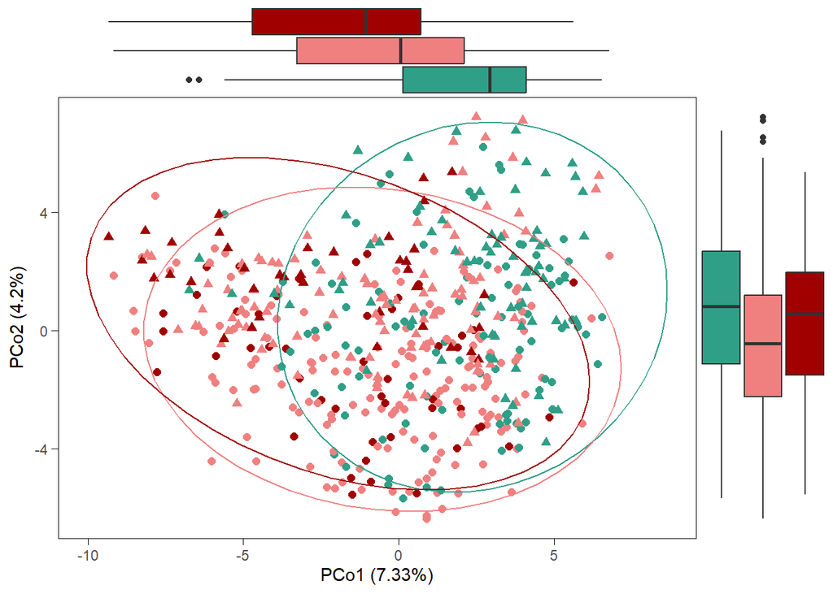

```r
p <- pca_plot_custom(filt_colon_genus_tab,
                                 filt_colon_genus_taxa,
                                 filt_colon_genus_metadata,
                                 show_boxplots = TRUE,
                                 variable = "Group", size=2,
                                 show_legend=FALSE)

# save the results
pca_plots_list[[paste(segment,level,"custom")]] <- p

# see the results
p
```

#### 3.3.1.1 Saving results

```r
write.xlsx(pairwise_aitchison_raw[[paste(level, segment)]],
           file = file.path(path,
           paste0("beta_diversity_results_", segment,".xlsx")))
```